# DS7337 Natural Language Processing

# 9 August 2020

1. Build a model then predict the sentiment based on a sequence of characters and a second model based on a sequence of bi-grams
   1. Sequence of Unigram Characters Model - Start
      1. Sequence of Unigram Characters Model - Model Results
   2. Sequence of Bi-Gram Characters Model
      1. Sequence of Bi-Gram Characters Model - Model Results
2. What is the vector you learned for the following emoji?
   1. Unigram Model Output for Emoji Embedding
   2. The vector learned for the emoji: 😂
      1. Loading the saved model
      2. Load the saved word list
      3. The learned vector for 😂
3. What is the most similar character for the emoji 😂?
4. Build a Universal Sentence Encoder (USE) Model and GRU
   1. Universal Sentence Encoder Models
      1. USE Model Results
   2. Gated Recurrent Unit Models
      1. GRU Model Results

```python
import pandas as pd
import numpy as np
import os
import re
import tensorflow as tf
# fix random seed for reproducibility
np.random.seed(7)

# display 400 characters of column width
pd.options.display.max_colwidth = 400
```

```python
print("Tensorflow version: {}".format(tf.__version__))
```

```
Tensorflow version: 2.2.0
```

# **PART I: Sequence of Characters (Unigram) Model**

Given the GOP twitter dataset (a dataset of tweets from 2012 with 3 sentiments—see the attached file)

# 1. Build a model then predict the sentiment (column “Sentiment”) of the tweet based on a sequence of characters and a second model based on a sequence of bi-grams (2-letter sequences).

I chose to use Gated Recurrent Unit (GRU) - as opposed to a Recurrent Neural Net (RNN) - because of the high volume of incomprehensible words such as hashtags (GOPdebate is one of the top words used in the whole dataset) and misspellings in the tweets. My opinion is that these words contribute greatly to the lack of confidence indicated in the tweet sentiment confidence provided for the pre-labeled sentiment classes.

Additionally, there are words that appear to have deep cultural meaning, such as the previously mentioned hashtags. I left these words in because the GRU can consider wider ranges of the sentence sequences simultaneously, thus capturing more of the context in which these words are repeatedly framed. For example, GOPdebate; while this word doesn't necessarily mean anything in terms of a word you would find in a traditional, academically accepted lexicon, there is underlying meaning which GRU is able to extract without resulting in a significant issue of vanishing gradients during back-propogation (an issue an RNN would likely suffer from). Therefore, by capturing meaning from these contexts, GRU is able to keep meaningful weights and biases for nodes that would otherwise be minimized from those vanishing gradients and thus result in the model's failure to continue learning. For this reason, I selected GRU as my model of choice.

```python
df = pd.read_csv('./Sentiment.csv')
```

### Important to note is that the provided confidence of the pre-labeling of Tweet sentiments is roughly 76%. Therefore, the benchmark of perfect model accuracy should approximate this value. Please see below:

```python
print("The average confidence of all pre-scored sentiments: {}%".format(100*round(df['sentiment_confidence'].mean(),4)))
```

```
The average confidence of all pre-scored sentiments: 75.69%
```

```python
len(df)
```

```
13871
```

```python
df_senti = df[['sentiment','text']]
```

### DATA-CLEANING-START

```python
def remove_specials(doc):
    """ removes all but alphanumeric, newline escape characters, and replaces hyphens with spaces for hyphenated words to not become one, but two"""
    doc = re.sub('-', ' ', doc)
    doc = re.sub('_', ' ', doc)
    pattern = r"[^a-zA-z0-9\s]+"
    doc = re.sub(pattern, '', doc)
    return doc
```

Note: This is a three-target-class predictive analysis

```python
df_senti.head()
```

|  | sentiment | text |
| --- | --- | --- |
| 0 | Neutral | RT @NancyLeeGrahn: How did everyone feel about the Climate Change question last night? Exactly. #GOPDebate |
| 1 | Positive | RT @ScottWalker: Didn't catch the full #GOPdebate last night. Here are some of Scott's best lines in 90 seconds. #Walker16 http://t.co/ZSfF… |
| 2 | Neutral | RT @TJMShow: No mention of Tamir Rice and the #GOPDebate was held in Cleveland? Wow. |
| 3 | Positive | RT @RobGeorge: That Carly Fiorina is trending -- hours after HER debate -- above any of the men in just-completed #GOPdebate says she's on … |
| 4 | Positive | RT @DanScavino: #GOPDebate w/ @realDonaldTrump delivered the highest ratings in the history of presidential debates. #Trump2016 http://t.co… |

```python
df_senti['sentiment'].replace("Negative", 0, inplace=True)
df_senti['sentiment'].replace("Neutral", 1, inplace=True)
df_senti['sentiment'].replace("Positive", 2, inplace=True)
```

```python
# df_senti['text'] = df_senti['text'].str.replace('http://', '', case=False)
# df_senti['text'] = df_senti['text'].str.replace('https://', '', case=False)
# df_senti['text'] = df_senti['text'].str.replace('http\S+|www.\S+', '', case=False)
# df_senti['text'] = df_senti['text'].str.replace('https\S+|www.\S+', '', case=False)
```

```python
for i in np.arange(0, len(df_senti)):
    if df_senti['text'][i].strip()[0:2] == "RT":
        df_senti['text'][i] = df_senti['text'][i][2:]

    df_senti['text'][i] = remove_specials(df_senti['text'][i])
```

```python
for i in np.arange(0,len(df_senti)):
    df_senti['text'][i] = ' '.join(word for word in df_senti['text'][i].split(' ') if not word.startswith('http'))
```

```python
len(df_senti)
```

```
13871
```

```python
df_senti['text'] = df_senti['text'].str.strip().str.lower()
```

```python
df_senti['text'].str.strip().isna().sum()
```

```
0
```

```python
for i in np.arange(len(df_senti['text'])):
    df_senti['text'][i] = df_senti['text'][i].replace('\\n', ' ')

for i in np.arange(len(df_senti['text'])):
    df_senti['text'][i] = df_senti['text'][i].replace("\n", "")
```

```python
df_senti.iloc[0,1].replace(' ', '')
```

```
'nancyleegrahnhowdideveryonefeelabouttheclimatechangequestionlastnightexactlygopdebate'
```

```python
#args=pd.DataFrame()
args=[]

for j in range(len(df_senti)):
    args.append(list([df_senti.iloc[j,1].replace(' ', '')[i:i+1] for i in range(len(df_senti.iloc[j,1].replace(' ', '')))]))
```

```python
args_frame = pd.Series(args).replace('', '')
args_frame
```

```
0                                                          [n, a, n, c, y, l, e, e, g, r, a, h, n, h, o, w, d, i, d, e, v, e, r, y, o, n, e, f, e, e, l, a, b, o, u, t, t, h, e, c, l, i, m, a, t, e, c, h, a, n, g, e, q, u, e, s, t, i, o, n, l, a, s, t, n, i, g, h, t, e, x, a, c, t, l, y, g, o, p, d, …
1                                  [s, c, o, t, t, w, a, l, k, e, r, d, i, d, n, t, c, a, t, c, h, t, h, e, f, u, l, l, g, o, p, d, e, b, a, t, e, l, a, s, t, n, i, g, h, t, h, e, r, e, a, r, e, s, o, m, e, o, f, s, c, o, t, t, s, b, e, s, t, l, i, n, e, s, i, n, 9, 0, s, e, c, o, n, d, s, w, a, l, …
2                                                                                                                            [t, j, m, s, h, o, w, n, o, m, e, n, t, i, o, n, o, f, t, a, m, i, r, r, i, c, e, a, n, d, t, h, e, g, o, p, d, e, b, a, t, e, w, a, s, h, e, l, d, i, n, c, l, e, v, e, l, a, …
3        [r, o, b, g, e, o, r, g, e, t, h, a, t, c, a, r, l, y, f, i, o, r, i, n, a, i, s, t, r, e, n, d, i, n, g, h, o, u, r, s, a, f, t, e, r, h, e, r, d, e, b, a, t, e, a, b, o, v, e, a, n, y, o, f, t, h, e, m, e, n, i, n, j, u, s, t, c, o, m, p, l, e, t, e, d, g, o, p, d, e, b, a, t, e, s, a, y,…
4        [d, a, n, s, c, a, v, i, n, o, g, o, p, d, e, b, a, t, e, w, r, e, a, l, d, o, n, a, l, d, t, r, u, m, p, d, e, l, i, v, e, r, e, d, t, h, e, h, i, g, h, e, s, t, r, a, t, i, n, g, s, i, n, t, h, e, h, i, s, t, o, r, y, o, f, p, r, e, s, i, d, e, n, t, i, a, l, d, e, b, a, t, e, s, t, r, u,…
                                                                                                                                                               ...
13866                  [c, a, p, p, y, y, a, r, b, r, o, u, g, h, l, o, v, e, t, o, s, e, e, m, e, n, w, h, o, w, i, l, l, n, e, v, e, r, b, e, f, a, c, e, d, w, i, t, h, a, p, r, e, g, n, a, n, c, y, t, a, l, k, a, b, o, u, t, w, h, a, t, i, c, a, n, d, o, w, i, t, h, m, y, b, o, d, y, g, o, p, d, …
13867    [g, e, o, r, g, e, h, e, n, r, y, w, w, h, o, t, h, o, u, g, h, t, h, u, c, k, a, b, e, e, e, x, c, e, e, d, e, d, t, h, e, i, r, e, x, p, e, c, t, a, t, i, o, n, s, g, o, p, d, e, b, a, t, e, i, m, w, i, t, h, h, u, c, k, g, o, p, c, c, o, t, t, e, a, p, a, r, t, y, t, c, o, t, l, a, u, r,…
13868                                                               [l, r, i, h, e, n, d, r, y, t, e, d, c, r, u, z, a, s, p, r, e, s, i, d, e, n, t, i, w, i, l, l, a, l, w, a, y, s, t, e, l, l, t, h, e, t, r, u, t, h, a, n, d, d, o, w, h, a, t, i, s, a, i, d, i, w, o, u, l, d, d, o, g, o, p, d, e, …
13869    [j, r, e, h, l, i, n, g, g, o, p, d, e, b, a, t, e, d, o, n, a, l, d, t, r, u, m, p, s, a, y, s, t, h, a, t, h, e, d, o, e, s, n, t, h, a, v, e, t, i, m, e, f, o, r, p, o, l, i, t, i, c, a, l, c, o, r, r, e, c, t, n, e, s, s, h, o, w, d, o, e, s, c, a, l, l, i, n, g, w, o, m, e, n, f, a, t,…
13870                                                                                                                        [l, r, i, h, e, n, d, r, y, t, e, d, c, r, u, z, h, e, a, d, e, d, i, n, t, o, t, h, e, p, r, e, s, i, d, e, n, t, i, a, l, d, e, b, a, t, e, s, g, o, t, e, d, g, o, p, d, e, …
Length: 13871, dtype: object
```

```python
for i in np.arange(len(args_frame)):
    args_frame[i] = ' '.join(args_frame[i])
```

```python
df_senti2 = pd.concat([df_senti['sentiment'],args_frame], axis=1)
df_senti2.columns = ['sentiment','text']
```

```python
df_senti2.head()
```

|  | sentiment | text |
| --- | --- | --- |
| 0 | 1 | n a n c y l e e g r a h n h o w d i d e v e r y o n e f e e l a b o u t t h e c l i m a t e c h a n g e q u e s t i o n l a s t n i g h t e x a c t l y g o p d e b a t e |
| 1 | 2 | s c o t t w a l k e r d i d n t c a t c h t h e f u l l g o p d e b a t e l a s t n i g h t h e r e a r e s o m e o f s c o t t s b e s t l i n e s i n 9 0 s e c o n d s w a l k e r 1 6 |
| 2 | 1 | t j m s h o w n o m e n t i o n o f t a m i r r i c e a n d t h e g o p d e b a t e w a s h e l d i n c l e v e l a n d w o w |
| 3 | 2 | r o b g e o r g e t h a t c a r l y f i o r i n a i s t r e n d i n g h o u r s a f t e r h e r d e b a t e a b o v e a n y o f t h e m e n i n j u s t c o m p l e t e d g o p d e b a t e s a y s s h … |
| 4 | 2 | d a n s c a v i n o g o p d e b a t e w r e a l d o n a l d t r u m p d e l i v e r e d t h e h i g h e s t r a t i n g s i n t h e h i s t o r y o f p r e s i d e n t i a l d e b a t e s t r u m p 2 … |

### DATA-CLEANING-EXIT

Function for adding the tweet words into a dictionary

```python
# put words into a dictionary for downstream use
import collections
def build_dataset(words):
    count = collections.Counter(words).most_common() #.most_common(100) to use the 100 most common words; .most_common() means zero is the most common
    dictionary = dict()
    for word, _ in count:
        dictionary[word] = len(dictionary)
    reverse_dictionary = dict(zip(dictionary.values(), dictionary.keys()))
    return dictionary, reverse_dictionary
```

## Encoding and decoding for the tweets, based on the word list.

```python
word_list = []

for i in df_senti2['text']:
    word_list = word_list + i.split()
```

```python
def encode_decode(input):
    enc, dec = build_dataset(word_list)
    return enc, dec
```

```python
enc, dec = encode_decode(word_list)
```

## Preparing padding and unknown tokens for each sequence (sentence). Tokens will be added downstream with pad_sequences().

Start by shifting all sequences by two places to insert in a pad token and an unknown token in index locations 0 and 1. These will be specified within the keras pre-processing pad_sequences function downstream once the desired maximum sequence length is determined based on sentence length distribution analysis. These tokens will be added to both the encoded and decoded.

Including an unknown token in the validation data is helpful for ensuring the model can avoid bias based on the words it knows in the event it encounters a new word it doesn't know. The patterns around the unknown word could match to the unknown marker so in the event there truly is a new word or new context for a word used, it will provide inference based on the pattern of the context rather than force it to match meaning to a word it does know, but does not apply for the context. This helps the model provide meaning to the context of what is being said rather than the words used, such as in the example "I'm feeling blue because something happened" vs. "the sky is blue because something happened."

```python
for i in enc:
    enc[i] = enc[i]+2 # shift everything by two so you can put in a pad and an unknown in index locations 0 and 1

                                                                    ###      ###
                                                                    # Encoding #
                                                                    ###      ###
enc['pad'] = 0

# start is useful for more complex architectures to invoke the LSTM to perform certain tasks, like decoding or recognizing the start of a sentence, for example.
#enc['<start>'] = 1

enc['<unk>'] = 1

                                                                    ###      ###
                                                                    # Decoding #
                                                                    ###      ###

# pad and include an unknown for the decoded values as well
dec[-2]='<pad>'
#dec[-1]='<start>'
dec[-1]='<unk>' # this is useful to indicate the LSTM should start decoding, or that this is the start of a sentence, or etc.
```

```python
import numpy as np
n=int(np.floor(df_senti2.shape[0]*0.75)) # 75% for training
train = df_senti2[0:n]
test = df_senti2[n:]
```

```python
train.head()
```

[output not shown]

```python
test.tail()
```

[output not shown]

## Summarizing train/test split balance

```python
train['sentiment'].value_counts()
```

```
0    6171
1    2531
2    1701
Name: sentiment, dtype: int64
```

```python
test['sentiment'].value_counts()
```

```
0    2322
1     611
2     535
Name: sentiment, dtype: int64
```

Optional training data balancing approach (consider the trade-off between overfitting and bias before committing to downsampling classes):

```python
# If you want to balance the training data:

# df1 = train[train['sentiment'] == 0]
# df1 = df1[:1701]

# df2 = train[train['sentiment'] == 1]
# df2 = df2[:1701]

# df3 = train[train['sentiment'] == 2]

# train = pd.concat([df1, df2, df3], axis=0)
```

```python
df_senti2['y'] = 0
df_senti2.loc[df_senti2['sentiment']==1,'y'] = 1
df_senti2.loc[df_senti2['sentiment']==2,'y'] = 2
```

```python
df_senti2.tail()
```

|  | sentiment | text | y |
| --- | --- | --- | --- |
| 13866 | 0 | c a p p y y a r b r o u g h l o v e t o s e e m e n w h o w i l l n e v e r b e f a c e d w i t h a p r e g n a n c y t a l k a b o u t w h a t i c a n d o w i t h m y b o d y g o p d e b a t e | 0 |
| 13867 | 2 | g e o r g e h e n r y w w h o t h o u g h t h u c k a b e e e x c e e d e d t h e i r e x p e c t a t i o n s g o p d e b a t e i m w i t h h u c k g o p c c o t t e a p a r t y t c o t l a u r a 4 f … | 2 |
| 13868 | 2 | l r i h e n d r y t e d c r u z a s p r e s i d e n t i w i l l a l w a y s t e l l t h e t r u t h a n d d o w h a t i s a i d i w o u l d d o g o p d e b a t e s | 2 |
| 13869 | 0 | j r e h l i n g g o p d e b a t e d o n a l d t r u m p s a y s t h a t h e d o e s n t h a v e t i m e f o r p o l i t i c a l c o r r e c t n e s s h o w d o e s c a l l i n g w o m e n f a t p i g … | 0 |
| 13870 | 2 | l r i h e n d r y t e d c r u z h e a d e d i n t o t h e p r e s i d e n t i a l d e b a t e s g o t e d g o p d e b a t e s | 2 |

```python
test.tail()
```

|  | sentiment | text | y |
| --- | --- | --- | --- |
| 13866 | 0 | c a p p y y a r b r o u g h l o v e t o s e e m e n w h o w i l l n e v e r b e f a c e d w i t h a p r e g n a n c y t a l k a b o u t w h a t i c a n d o w i t h m y b o d y g o p d e b a t e | 0 |
| 13867 | 2 | g e o r g e h e n r y w w h o t h o u g h t h u c k a b e e e x c e e d e d t h e i r e x p e c t a t i o n s g o p d e b a t e i m w i t h h u c k g o p c c o t t e a p a r t y t c o t l a u r a 4 f … | 2 |
| 13868 | 2 | l r i h e n d r y t e d c r u z a s p r e s i d e n t i w i l l a l w a y s t e l l t h e t r u t h a n d d o w h a t i s a i d i w o u l d d o g o p d e b a t e s | 2 |
| 13869 | 0 | j r e h l i n g g o p d e b a t e d o n a l d t r u m p s a y s t h a t h e d o e s n t h a v e t i m e f o r p o l i t i c a l c o r r e c t n e s s h o w d o e s c a l l i n g w o m e n f a t p i g … | 0 |
| 13870 | 2 | l r i h e n d r y t e d c r u z h e a d e d i n t o t h e p r e s i d e n t i a l d e b a t e s g o t e d g o p d e b a t e s | 2 |

```python
test.shape[0]
```

```
3468
```

# Creating test examples for encoding and decoding sentences

```python
x_train=[]
y_train=[]

for i in range(train.shape[0]):
    tmp = [enc[j] for j in train.iloc[i,1].split()] # enc[j]: the j (list expression) is encoding the number for the word in the encoded matrix (i,j)
    x_train.append(tmp) # append the newly replaced word
    if train.iloc[i,0]==0: # re-encode y in the below
        y=0
    elif train.iloc[i,0]==1: # re-encode y in the below
        y=1
    else:
        y=2
    y_train.append(y) # append the newly encoded y here

x_test=[] # repeat for the test data the steps performed above for training data
y_test=[]
for i in range(test.shape[0]):
    tmp = [enc[j] for j in test.iloc[i,1].split()]
    x_test.append(tmp)
    if test.iloc[i,0]==0: # re-encode y in the below
        y=0
    elif test.iloc[i,0]==1: # re-encode y in the below
        y=1
    else:
        y=2
    y_test.append(y)
```

```python
len(y_train)
```

```
10403
```

```python
np.unique(y_train)
```

```
array([0, 1, 2])
```

```python
np.unique(y_test)
```

```
array([0, 1, 2])
```

```python
len(x_train)
```

```
10403
```

```python
len(x_test)
```

```
3468
```

```python
df_senti2.iloc[0,1]
```

```
'n a n c y l e e g r a h n h o w d i d e v e r y o n e f e e l a b o u t t h e c l i m a t e c h a n g e q u e s t i o n l a s t n i g h t e x a c t l y g o p d e b a t e'
```

# Deciding the maximum vector sequence length

Here, I visualize the distribution of word counts in each tweet, then use the 90th percentile. If results aren't satisfactory, I can increase the percentile - to 95%, for example - but the 90th percentile is healthy for preventing overfitting.

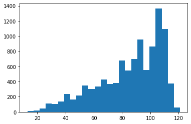

```python
import matplotlib.pyplot as plt

lengths=[]

for i in x_train:
    lengths.append(len(i))

%matplotlib inline
plt.hist(lengths,bins=25)
```

```python
print("Sentence with least unigrams (characters) has {} characters.".format(min(lengths)))
```

```
Sentence with least unigrams (characters) has 13 characters.
```

```python
print("90th percentile of all tweet character count volumes: {}".format(int(np.percentile(lengths, 90))))
```

```
90th percentile of all tweet character count volumes: 110
```

```python
print("Two standard-deviation range: {}\n".format([np.asarray(lengths).mean() - 2 * np.asarray(lengths).std(), np.asarray(lengths).mean() + 2 * np.asarray(lengths).std()]))
```

```
Two standard-deviation range: [40.18384327932684, 131.02004021581877]
```

### Normalizing sentence word length by adding the padding and unknown tokens to the sequences (prepared above)

```python
from tensorflow.keras.preprocessing import sequence
# Because most of the reviews in the histogram above are length 23 or less, setting max_length to 23 words:
max_length = 110
x_train = sequence.pad_sequences(x_train, maxlen = max_length)
x_test = sequence.pad_sequences(x_test, maxlen = max_length)
```

```python
# Load Neural Nets
from tensorflow.keras.layers import Dense, Embedding
from tensorflow.keras.models import Sequential
from tensorflow.keras.preprocessing import sequence
from tensorflow.keras.layers import GRU
from tensorflow.keras.callbacks import EarlyStopping
```

```python
x_train.shape
```

```
(10403, 110)
```

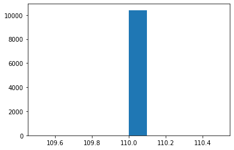

```python
%matplotlib inline
import matplotlib.pyplot as plt
plt.hist([len(i) for i in x_train])
plt.show()
### Note that after padding, all sentences are the same length (same number of parameters)
```

# Sequence of Characters Model Output

```
WARNING:tensorflow:Layer gru_2 will not use cuDNN kernel since it doesn't meet the cuDNN kernel criteria. It will use generic GPU kernel as fallback when running on GPU
Model: "sequential_2"
_________________________________________________________________
Layer (type)                 Output Shape              Param #
=================================================================
embedding_2 (Embedding)      (None, 110, 80)           3440
_________________________________________________________________
gru_2 (GRU)                  (None, 100)               54600
_________________________________________________________________
dense_2 (Dense)              (None, 3)                 303
=================================================================
Total params: 58,343
Trainable params: 58,343
Non-trainable params: 0
_________________________________________________________________
None
```

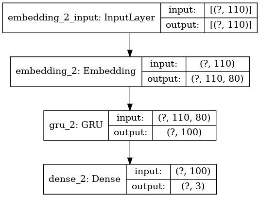

```python
from keras.utils import plot_model
callback = tf.keras.callbacks.EarlyStopping(monitor='loss', patience=3)

embedding_vector_length = 80
model1 = Sequential()
model1.add(Embedding(len(dec), embedding_vector_length, input_length=max_length))
model1.add(GRU(100, unroll=True, dropout=0.2)) # unroll makes this run faster; units between 100-300
model1.add(Dense(3, activation='softmax')) # 3 for the three classes
model1.compile(loss='sparse_categorical_crossentropy', optimizer='rmsprop', metrics=['accuracy']) # rmsprop did better than adam
print(model1.summary())

plot_model(model1, to_file='model_plot4a.png', show_shapes=True, show_layer_names=True)
```

```python
model_GRU = model1.fit(x_train
                       , np.array(y_train)
                       , validation_data=(x_test, np.array(y_test))
                       , callbacks=[callback] # EarlyStopping
                       , epochs=20
                       , batch_size=32)
```

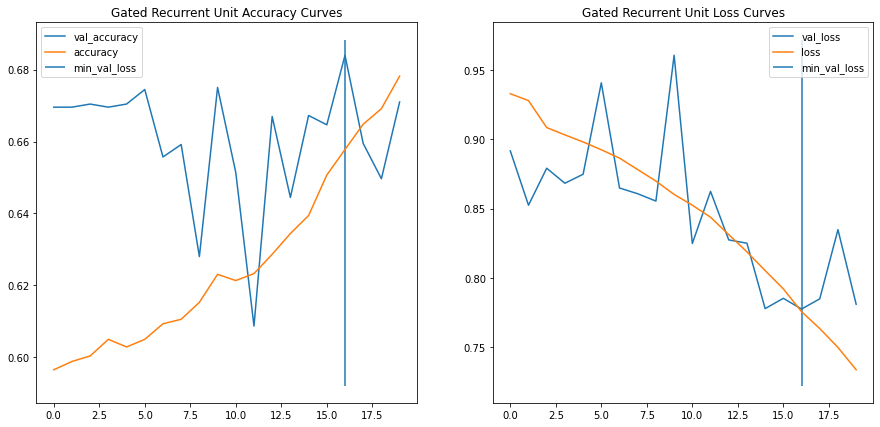

```python
val_loss = model_GRU.history['val_loss']
min_loss_loc = np.where(val_loss==np.min(val_loss))[0][0]

fig, ax = plt.subplots(ncols=2, figsize = (15,7))
ax[0].plot(model_GRU.history['val_accuracy'], label = 'val_accuracy')
ax[0].plot(model_GRU.history['accuracy'], label = 'accuracy')
ax[0].vlines(min_loss_loc, *ax[0].get_ylim(), label = 'min_val_loss')
ax[0].set_title('Gated Recurrent Unit Accuracy Curves')
ax[0].legend();

ax[1].plot(model_GRU.history['val_loss'], label = 'val_loss')
ax[1].plot(model_GRU.history['loss'], label = 'loss')
ax[1].vlines(min_loss_loc, *ax[1].get_ylim(), label = 'min_val_loss')
ax[1].set_title('Gated Recurrent Unit Loss Curves')
ax[1].legend();
```

```python
model_GRU = model1.fit(x_train
                       , np.array(y_train)
                       , validation_data=(x_test, np.array(y_test))
                       , callbacks=[callback]
                       , epochs=20
                       , batch_size=16)
```

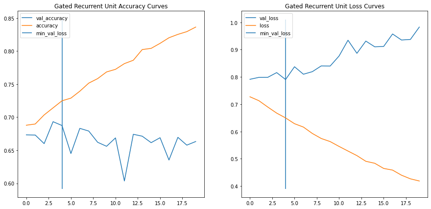

```python
val_loss = model_GRU.history['val_loss']
min_loss_loc = np.where(val_loss==np.min(val_loss))[0][0]

fig, ax = plt.subplots(ncols=2, figsize = (15,7))
ax[0].plot(model_GRU.history['val_accuracy'], label = 'val_accuracy')
ax[0].plot(model_GRU.history['accuracy'], label = 'accuracy')
ax[0].vlines(min_loss_loc, *ax[0].get_ylim(), label = 'min_val_loss')
ax[0].set_title('Gated Recurrent Unit Accuracy Curves')
ax[0].legend();

ax[1].plot(model_GRU.history['val_loss'], label = 'val_loss')
ax[1].plot(model_GRU.history['loss'], label = 'loss')
ax[1].vlines(min_loss_loc, *ax[1].get_ylim(), label = 'min_val_loss')
ax[1].set_title('Gated Recurrent Unit Loss Curves')
ax[1].legend();
```

```python
model_GRU = model1.fit(x_train
                       , np.array(y_train)
                       , validation_data=(x_test, np.array(y_test))
                       , callbacks=[callback]
                       , epochs=20
                       , batch_size=64)
```

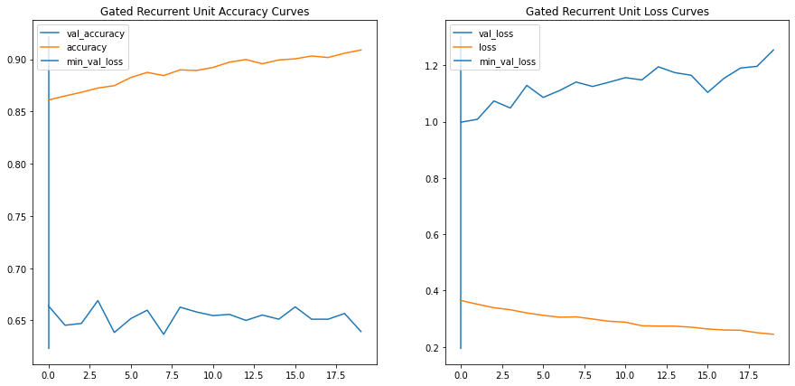

```python
val_loss = model_GRU.history['val_loss']
min_loss_loc = np.where(val_loss==np.min(val_loss))[0][0]

fig, ax = plt.subplots(ncols=2, figsize = (15,7))
ax[0].plot(model_GRU.history['val_accuracy'], label = 'val_accuracy')
ax[0].plot(model_GRU.history['accuracy'], label = 'accuracy')
ax[0].vlines(min_loss_loc, *ax[0].get_ylim(), label = 'min_val_loss')
ax[0].set_title('Gated Recurrent Unit Accuracy Curves')
ax[0].legend();

ax[1].plot(model_GRU.history['val_loss'], label = 'val_loss')
ax[1].plot(model_GRU.history['loss'], label = 'loss')
ax[1].vlines(min_loss_loc, *ax[1].get_ylim(), label = 'min_val_loss')
ax[1].set_title('Gated Recurrent Unit Loss Curves')
ax[1].legend();
```

# **PART I: Sequence of Bi-gram (2-letter sequences) Model**

```python
df_senti.iloc[0,1].replace(' ', '')
```

```
'nancyleegrahnhowdideveryonefeelabouttheclimatechangequestionlastnightexactlygopdebate'
```

```python
#args=pd.DataFrame()
args=[]

for j in range(len(df_senti)):
    args.append(list([df_senti.iloc[j,1].replace(' ', '')[i:i+2] for i in range(len(df_senti.iloc[j,1].replace(' ', '')))]))
```

Stripping quotes:

```python
args_frame = pd.Series(args).replace('', '')
args_frame
```

```
0                                                                    [na, an, nc, cy, yl, le, ee, eg, gr, ra, ah, hn, nh, ho, ow, wd, di, id, de, ev, ve, er, ry, yo, on, ne, ef, fe, ee, el, la, ab, bo, ou, ut, tt, th, he, ec, cl, li, im, ma, at, te, ec, ch, ha, an, ng, ge, eq, qu, ue, es, st, ti, io…
1                                    [sc, co, ot, tt, tw, wa, al, lk, ke, er, rd, di, id, dn, nt, tc, ca, at, tc, ch, ht, th, he, ef, fu, ul, ll, lg, go, op, pd, de, eb, ba, at, te, el, la, as, st, tn, ni, ig, gh, ht, th, he, er, re, ea, ar, re, es, so, om, me, eo, of, fs, sc, co, ot, tt, ts, sb, be…
2                                                                                                                                                            [tj, jm, ms, sh, ho, ow, wn, no, om, me, en, nt, ti, io, on, no, of, ft, ta, am, mi, ir, rr, ri, ic, ce, ea, an, nd, dt, th, he, eg, go, op, pd…
3        [ro, ob, bg, ge, eo, or, rg, ge, et, th, ha, at, tc, ca, ar, rl, ly, yf, fi, io, or, ri, in, na, ai, is, st, tr, re, en, nd, di, in, ng, gh, ho, ou, ur, rs, sa, af, ft, te, er, rh, he, er, rd, de, eb, ba, at, te, ea, ab, bo, ov, ve, ea, an, ny, yo, of, ft, th, he, em, me, en, ni, in, nj, ju…
4        [da, an, ns, sc, ca, av, vi, in, no, og, go, op, pd, de, eb, ba, at, te, ew, wr, re, ea, al, ld, do, on, na, al, ld, dt, tr, ru, um, mp, pd, de, el, li, iv, ve, er, re, ed, dt, th, he, eh, hi, ig, gh, he, es, st, tr, ra, at, ti, in, ng, gs, si, in, nt, th, he, eh, hi, is, st, to, or, ry, yo…
                                                                                                                                                                                                              ...
13866                [ca, ap, pp, py, yy, ya, ar, rb, br, ro, ou, ug, gh, hl, lo, ov, ve, et, to, os, se, ee, em, me, en, nw, wh, ho, ow, wi, il, ll, ln, ne, ev, ve, er, rb, be, ef, fa, ac, ce, ed, dw, wi, it, th, ha, ap, pr, re, eg, gn, na, an, nc, cy, yt, ta, al, lk, ka, ab, bo, ou, ut, tw, wh, ha…
13867    [ge, eo, or, rg, ge, eh, he, en, nr, ry, yw, ww, wh, ho, ot, th, ho, ou, ug, gh, ht, th, hu, uc, ck, ka, ab, be, ee, ee, ex, xc, ce, ee, ed, de, ed, dt, th, he, ei, ir, re, ex, xp, pe, ec, ct, ta, at, ti, io, on, ns, sg, go, op, pd, de, eb, ba, at, te, ei, im, mw, wi, it, th, hh, hu, uc, ck…
13868                                                                            [lr, ri, ih, he, en, nd, dr, ry, yt, te, ed, dc, cr, ru, uz, za, as, sp, pr, re, es, si, id, de, en, nt, ti, iw, wi, il, ll, la, al, lw, wa, ay, ys, st, te, el, ll, lt, th, he, et, tr, ru, ut, th, ha, an, nd, dd, do, ow…
13869    [jr, re, eh, hl, li, in, ng, gg, go, op, pd, de, eb, ba, at, te, ed, do, on, na, al, ld, dt, tr, ru, um, mp, ps, sa, ay, ys, st, th, ha, at, th, he, ed, do, oe, es, sn, nt, th, ha, av, ve, et, ti, im, me, ef, fo, or, rp, po, ol, li, it, ti, ic, ca, al, lc, co, or, rr, re, ec, ct, tn, ne, es…
13870                                                                                                                                                        [lr, ri, ih, he, en, nd, dr, ry, yt, te, ed, dc, cr, ru, uz, zh, he, ea, ad, de, ed, di, in, nt, to, ot, th, he, ep, pr, re, es, si, id, de, en…
Length: 13871, dtype: object
```

### Stripping commas:

```python
for i in np.arange(len(args_frame)):
    args_frame[i] = ' '.join(args_frame[i])
```

Checking the first index (and comparing to above):

```python
args_frame[0]
```

```
'na an nc cy yl le ee eg gr ra ah hn nh ho ow wd di id de ev ve er ry yo on ne ef fe ee el la ab bo ou ut tt th he ec cl li im ma at te ec ch ha an ng ge eq qu ue es st ti io on nl la as st tn ni ig gh ht te ex xa ac ct tl ly yg go op pd de eb ba at te e'
```

Checking the last index (and comparing to above):

```python
args_frame[-1:]
```

```
13870    lr ri ih he en nd dr ry yt te ed dc cr ru uz zh he ea ad de ed di in nt to ot th he ep pr re es si id de en nt ti ia al ld de eb ba at te es sg go ot te ed dg go op pd de eb ba at te es s
dtype: object
```

```python
for i in np.arange(len(args_frame)):
    args_frame[i] = args_frame[i].replace('\\n', ' ')
```

```python
for i in np.arange(len(args_frame)):
    args_frame[i] = args_frame[i].replace("\n", "")
```

Confirming new length matches original length to ensure no data was inadvertantly truncated before concatenating back to form a character bi-grammed dataset:

```python
len(args_frame)
```

```
13871
```

```python
len(df_senti['sentiment'])
```

```
13871
```

```python
df_senti2 = pd.concat([df_senti['sentiment'],args_frame], axis=1)
```

```python
len(df_senti2)
```

```
13871
```

```python
df_senti2.columns = ['sentiment','text']
```

```python
df_senti2.head(12)
```

|  | sentiment | text |
| --- | --- | --- |
| 0 | 1 | na an nc cy yl le ee eg gr ra ah hn nh ho ow wd di id de ev ve er ry yo on ne ef fe ee el la ab bo ou ut tt th he ec cl li im ma at te ec ch ha an ng ge eq qu ue es st ti io on nl la as st tn ni ig gh… |
| 1 | 2 | sc co ot tt tw wa al lk ke er rd di id dn nt tc ca at tc ch ht th he ef fu ul ll lg go op pd de eb ba at te el la as st tn ni ig gh ht th he er re ea ar re es so om me eo of fs sc co ot tt ts sb be es… |
| 2 | 1 | tj jm ms sh ho ow wn no om me en nt ti io on no of ft ta am mi ir rr ri ic ce ea an nd dt th he eg go op pd de eb ba at te ew wa as sh he el ld di in nc cl le ev ve el la an nd dw wo ow w |
| 3 | 2 | ro ob bg ge eo or rg ge et th ha at tc ca ar rl ly yf fi io or ri in na ai is st tr re en nd di in ng gh ho ou ur rs sa af ft te er rh he er rd de eb ba at te ea ab bo ov ve ea an ny yo of ft th he em… |
| 4 | 2 | da an ns sc ca av vi in no og go op pd de eb ba at te ew wr re ea al ld do on na al ld dt tr ru um mp pd de el li iv ve er re ed dt th he eh hi ig gh he es st tr ra at ti in ng gs si in nt th he eh hi… |
| 5 | 2 | gr re eg ga ab bb bo ot tt tt tx xt te ed dc cr ru uz zo on nm my yf fi ir rs st td da ay yi iw wi il ll lr re es sc ci in nd de ev ve er ry yi il ll le eg ga al le ex xe ec cu ut ti iv ve ea ac ct ti… |
| 6 | 0 | wa ar rr ri io or rw wo om ma an n9 91 1i il li ik ke ed dh he er ra an nd dw wa as sh ha ap pp py yw wh he en ni ih he ea ar rd ds sh he ew wa as sg go oi in ng gt to ob be et th he em mo od de er ra… |
| 7 | 1 | go oi in ng go on nm ms sn nb bc cl li iv ve ew wi it th ht th ho om ma as sa ar ro ob be er rt ts sa ar ro ou un nd d2 2p pm me et tg go op pd de eb ba at te e |
| 8 | 0 | de ee er ri in nt th he eh he ea ad dl li ig gh ht ts sr rt tl li iz zz zw wi in ns st te ea ad db be en nc ca ar rs so on nm ma ay yb be et th he eo on nl ly yb br ra ai in ns su ur rg ge eo on nw wh… |
| 9 | 0 | na an nc cy yo os sb bo or rn ne e1 18 80 0l la as st tn ni ig gh ht ts sd de eb ba at te ep pr ro ov ve ed di it tg go op pd de eb ba at te eb ba at ts sa as sk kb ba ad da as ss st te ea ac ch he er… |
| 10 | 0 | jg gr re ee en nd dc cr re ea al ld do on na al ld dt tr ru um mp pi in na al ll lf fa ai ir rn ne es ss sb bi il ll lc cl li in nt to on no ow wn ns st th ha at tp ph hr ra as se eg go op pd de eb ba… |
| 11 | 2 | wa ay yn ne ed du up pr re ee es sh ho ow wj ju us st tw wo ok ke eu up pt to ot tw we ee et tt th hi is so ou ut tg go op pd de eb ba at te eb be es st tl li in ne eo of ft th he en ni ig gh ht tv vi… |

```python
word_list = []

for i in df_senti2['text']:
    word_list = word_list + i.split()
```

```python
enc, dec = encode_decode(word_list)
```

```python
df_senti2['y'] = 0
df_senti2.loc[df_senti2['sentiment']==1,'y'] = 1
df_senti2.loc[df_senti2['sentiment']==2,'y'] = 2
```

```python
df_senti2.head()
```

|  | sentiment | text | y |
| --- | --- | --- | --- |
| 0 | 1 | na an nc cy yl le ee eg gr ra ah hn nh ho ow wd di id de ev ve er ry yo on ne ef fe ee el la ab bo ou ut tt th he ec cl li im ma at te ec ch ha an ng ge eq qu ue es st ti io on nl la as st tn ni ig gh… | 1 |
| 1 | 2 | sc co ot tt tw wa al lk ke er rd di id dn nt tc ca at tc ch ht th he ef fu ul ll lg go op pd de eb ba at te el la as st tn ni ig gh ht th he er re ea ar re es so om me eo of fs sc co ot tt ts sb be es… | 2 |
| 2 | 1 | tj jm ms sh ho ow wn no om me en nt ti io on no of ft ta am mi ir rr ri ic ce ea an nd dt th he eg go op pd de eb ba at te ew wa as sh he el ld di in nc cl le ev ve el la an nd dw wo ow w | 1 |
| 3 | 2 | ro ob bg ge eo or rg ge et th ha at tc ca ar rl ly yf fi io or ri in na ai is st tr re en nd di in ng gh ho ou ur rs sa af ft te er rh he er rd de eb ba at te ea ab bo ov ve ea an ny yo of ft th he em… | 2 |
| 4 | 2 | da an ns sc ca av vi in no og go op pd de eb ba at te ew wr re ea al ld do on na al ld dt tr ru um mp pd de el li iv ve er re ed dt th he eh hi ig gh he es st tr ra at ti in ng gs si in nt th he eh hi… | 2 |

```python
import numpy as np
n=int(np.floor(df_senti2.shape[0]*0.75)) # 75% for training
train = df_senti2[0:n]
test = df_senti2[n:]
```

```python
train['sentiment'].value_counts()
```

```
0    6171
1    2531
2    1701
Name: sentiment, dtype: int64
```

```python
test['sentiment'].value_counts()
```

```
0    2322
1     611
2     535
Name: sentiment, dtype: int64
```

```python
train.head(12)
```

|  | sentiment | text | y |
| --- | --- | --- | --- |
| 0 | 1 | na an nc cy yl le ee eg gr ra ah hn nh ho ow wd di id de ev ve er ry yo on ne ef fe ee el la ab bo ou ut tt th he ec cl li im ma at te ec ch ha an ng ge eq qu ue es st ti io on nl la as st tn ni ig gh… | 1 |
| 1 | 2 | sc co ot tt tw wa al lk ke er rd di id dn nt tc ca at tc ch ht th he ef fu ul ll lg go op pd de eb ba at te el la as st tn ni ig gh ht th he er re ea ar re es so om me eo of fs sc co ot tt ts sb be es… | 2 |
| 2 | 1 | tj jm ms sh ho ow wn no om me en nt ti io on no of ft ta am mi ir rr ri ic ce ea an nd dt th he eg go op pd de eb ba at te ew wa as sh he el ld di in nc cl le ev ve el la an nd dw wo ow w | 1 |
| 3 | 2 | ro ob bg ge eo or rg ge et th ha at tc ca ar rl ly yf fi io or ri in na ai is st tr re en nd di in ng gh ho ou ur rs sa af ft te er rh he er rd de eb ba at te ea ab bo ov ve ea an ny yo of ft th he em… | 2 |
| 4 | 2 | da an ns sc ca av vi in no og go op pd de eb ba at te ew wr re ea al ld do on na al ld dt tr ru um mp pd de el li iv ve er re ed dt th he eh hi ig gh he es st tr ra at ti in ng gs si in nt th he eh hi… | 2 |
| 5 | 2 | gr re eg ga ab bb bo ot tt tt tx xt te ed dc cr ru uz zo on nm my yf fi ir rs st td da ay yi iw wi il ll lr re es sc ci in nd de ev ve er ry yi il ll le eg ga al le ex xe ec cu ut ti iv ve ea ac ct ti… | 2 |
| 6 | 0 | wa ar rr ri io or rw wo om ma an n9 91 1i il li ik ke ed dh he er ra an nd dw wa as sh ha ap pp py yw wh he en ni ih he ea ar rd ds sh he ew wa as sg go oi in ng gt to ob be et th he em mo od de er ra… | 0 |
| 7 | 1 | go oi in ng go on nm ms sn nb bc cl li iv ve ew wi it th ht th ho om ma as sa ar ro ob be er rt ts sa ar ro ou un nd d2 2p pm me et tg go op pd de eb ba at te e | 1 |
| 8 | 0 | de ee er ri in nt th he eh he ea ad dl li ig gh ht ts sr rt tl li iz zz zw wi in ns st te ea ad db be en nc ca ar rs so on nm ma ay yb be et th he eo on nl ly yb br ra ai in ns su ur rg ge eo on nw wh… | 0 |
| 9 | 0 | na an nc cy yo os sb bo or rn ne e1 18 80 0l la as st tn ni ig gh ht ts sd de eb ba at te ep pr ro ov ve ed di it tg go op pd de eb ba at te eb ba at ts sa as sk kb ba ad da as ss st te ea ac ch he er… | 0 |
| 10 | 0 | jg gr re ee en nd dc cr re ea al ld do on na al ld dt tr ru um mp pi in na al ll lf fa ai ir rn ne es ss sb bi il ll lc cl li in nt to on no ow wn ns st th ha at tp ph hr ra as se eg go op pd de eb ba… | 0 |
| 11 | 2 | wa ay yn ne ed du up pr re ee es sh ho ow wj ju us st tw wo ok ke eu up pt to ot tw we ee et tt th hi is so ou ut tg go op pd de eb ba at te eb be es st tl li in ne eo of ft th he en ni ig gh ht tv vi… | 2 |

```python
train.shape[0]
```

```
10403
```

```python
test.shape[0]
```

```
3468
```

```python
x_train=[]
y_train=[]

for i in range(train.shape[0]):
    tmp = [enc[j] for j in train.iloc[i,1].split()] # enc[j]: the j (list expression) is encoding the number for the word in the encoded matrix (i,j)
    x_train.append(tmp) # append the newly replaced word
    if train.iloc[i,0]==0: # re-encode y in the below
        y=0
    elif train.iloc[i,0]==1: # re-encode y in the below
        y=1
    else:
        y=2
    y_train.append(y) # append the newly encoded y here

x_test=[] # repeat for the test data the steps performed above for training data
y_test=[]
for i in range(test.shape[0]):
    tmp = [enc[j] for j in test.iloc[i,1].split()]
    x_test.append(tmp)
    if test.iloc[i,0]==0: # re-encode y in the below
        y=0
    elif test.iloc[i,0]==1: # re-encode y in the below
        y=1
    else:
        y=2
    y_test.append(y)
```

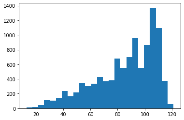

```python
import matplotlib.pyplot as plt

lengths=[]

for i in x_train:
    lengths.append(len(i))

%matplotlib inline
plt.hist(lengths,bins=25)
```

```python
min(lengths)
```

```
13
```

```python
max(lengths)
```

```
125
```

Here, because of the volume of bigrams, I've chosen to use the 95th percentile whereas with the unigram approach, I chose to use the 90th percentile. There's less risk of overfitting here.

```python
int(np.percentile(lengths, 95))
```

```
112
```

```python
print([np.asarray(lengths).mean() - 2 * np.asarray(lengths).std(), np.asarray(lengths).mean() + 2 * np.asarray(lengths).std()])
```

```
[40.18374336828807, 131.02148589250208]
```

```python
from tensorflow.keras.preprocessing import sequence
# Because most of the reviews in the histogram above are length 23 or less, setting max_length to 23 words:
max_length = 112
x_train = sequence.pad_sequences(x_train, maxlen = max_length)
x_test = sequence.pad_sequences(x_test, maxlen = max_length)
```

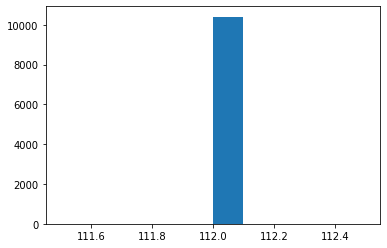

```python
%matplotlib inline
import matplotlib.pyplot as plt
plt.hist([len(i) for i in x_train])
plt.show()
### Note that after padding, all sentences are the same length (same number of parameters)
```

```python
len(x_train)
```

```
10403
```

# Sequence of Bi-Grams Model Output

```
WARNING:tensorflow:Layer gru_1 will not use cuDNN kernel since it doesn't meet the cuDNN kernel criteria. It will use generic GPU kernel as fallback when running on GPU
Model: "sequential_1"
_________________________________________________________________
Layer (type)                 Output Shape              Param #
=================================================================
embedding_1 (Embedding)      (None, 112, 128)          169344
_________________________________________________________________
gru_1 (GRU)                  (None, 100)               69000
_________________________________________________________________
dense_1 (Dense)              (None, 3)                 303
=================================================================
Total params: 238,647
Trainable params: 238,647
Non-trainable params: 0
_________________________________________________________________
None
```

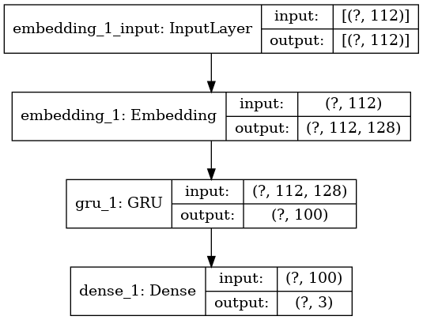

```python
embedding_vector_length = 128
model1 = Sequential()
model1.add(Embedding(len(dec), embedding_vector_length, input_length=max_length))
model1.add(GRU(100, unroll=True, dropout=0.2)) # unroll makes this run faster
model1.add(Dense(3, activation='softmax'))
#model1.compile(loss='binary_crossentropy', optimizer='adam', metrics=['accuracy'])
model1.compile(loss='sparse_categorical_crossentropy', optimizer='rmsprop', metrics=['accuracy'])
print(model1.summary())

plot_model(model1, to_file='model_plot4a.png', show_shapes=True, show_layer_names=True)
```

```python
model_GRU = model1.fit(x_train
                       , np.array(y_train)
                       , validation_data=(x_test, np.array(y_test))
                       , callbacks=[callback]
                       , epochs=20
                       , batch_size=32)
```

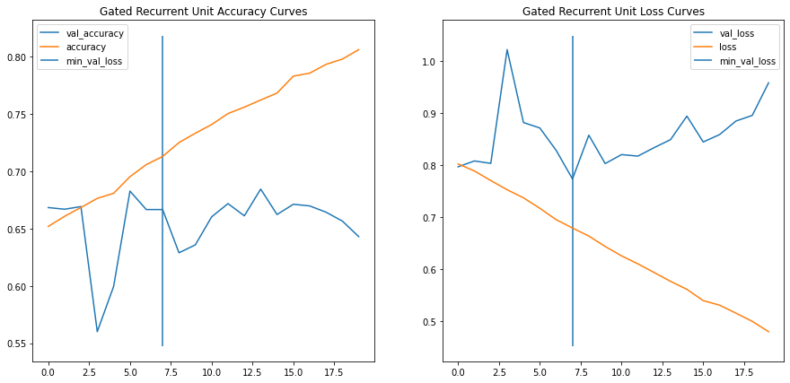

```python
val_loss = model_GRU.history['val_loss']
min_loss_loc = np.where(val_loss==np.min(val_loss))[0][0]

fig, ax = plt.subplots(ncols=2, figsize = (15,7))
ax[0].plot(model_GRU.history['val_accuracy'], label = 'val_accuracy')
ax[0].plot(model_GRU.history['accuracy'], label = 'accuracy')
ax[0].vlines(min_loss_loc, *ax[0].get_ylim(), label = 'min_val_loss')
ax[0].set_title('Gated Recurrent Unit Accuracy Curves')
ax[0].legend();

ax[1].plot(model_GRU.history['val_loss'], label = 'val_loss')
ax[1].plot(model_GRU.history['loss'], label = 'loss')
ax[1].vlines(min_loss_loc, *ax[1].get_ylim(), label = 'min_val_loss')
ax[1].set_title('Gated Recurrent Unit Loss Curves')
ax[1].legend();
```

```python
model_GRU = model1.fit(x_train
                       , np.array(y_train)
                       , validation_data=(x_test, np.array(y_test))
                       , callbacks=[callback]
                       , epochs=20
                       , batch_size=16)
```

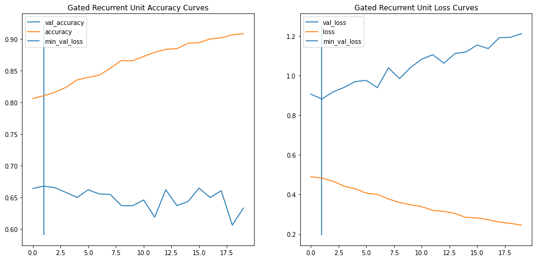

```python
val_loss = model_GRU.history['val_loss']
min_loss_loc = np.where(val_loss==np.min(val_loss))[0][0]

fig, ax = plt.subplots(ncols=2, figsize = (15,7))
ax[0].plot(model_GRU.history['val_accuracy'], label = 'val_accuracy')
ax[0].plot(model_GRU.history['accuracy'], label = 'accuracy')
ax[0].vlines(min_loss_loc, *ax[0].get_ylim(), label = 'min_val_loss')
ax[0].set_title('Gated Recurrent Unit Accuracy Curves')
ax[0].legend();

ax[1].plot(model_GRU.history['val_loss'], label = 'val_loss')
ax[1].plot(model_GRU.history['loss'], label = 'loss')
ax[1].vlines(min_loss_loc, *ax[1].get_ylim(), label = 'min_val_loss')
ax[1].set_title('Gated Recurrent Unit Loss Curves')
ax[1].legend();
```

```python
model_GRU = model1.fit(x_train
                       , np.array(y_train)
                       , validation_data=(x_test, np.array(y_test))
                       , callbacks=[callback]
                       , epochs=20
                       , batch_size=64)
```

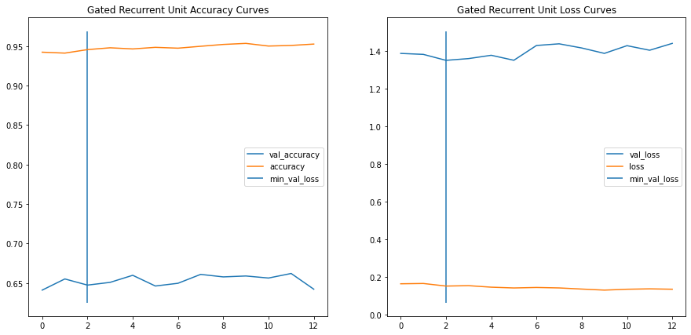

```python
val_loss = model_GRU.history['val_loss']
min_loss_loc = np.where(val_loss==np.min(val_loss))[0][0]

fig, ax = plt.subplots(ncols=2, figsize = (15,7))
ax[0].plot(model_GRU.history['val_accuracy'], label = 'val_accuracy')
ax[0].plot(model_GRU.history['accuracy'], label = 'accuracy')
ax[0].vlines(min_loss_loc, *ax[0].get_ylim(), label = 'min_val_loss')
ax[0].set_title('Gated Recurrent Unit Accuracy Curves')
ax[0].legend();

ax[1].plot(model_GRU.history['val_loss'], label = 'val_loss')
ax[1].plot(model_GRU.history['loss'], label = 'loss')
ax[1].vlines(min_loss_loc, *ax[1].get_ylim(), label = 'min_val_loss')
ax[1].set_title('Gated Recurrent Unit Loss Curves')
ax[1].legend();
```

# 2. What is the vector you learned for the following emoji.

For parts 2 and 3, I used the findings and pre-trained vectors (in the binary file) from the *Learning Emoji Representations from their Description* research paper and project. I used the Gensim library to load the pre-trained vectors and guage cosine similarity to identify the closest matching emojis.

Paper: https://arxiv.org/pdf/1609.08359.pdf </br> GitHub (pre-trained vectors): https://github.com/uclnlp/emoji2vec

```python
import pandas as pd
import numpy as np
import os
import re
import tensorflow as tf
# fix random seed for reproducibility
np.random.seed(7)

# display 400 characters of column width
pd.options.display.max_colwidth = 400
```

### This cleaning process is the same as for the unigram modeling approach

```python
df = pd.read_csv('./Sentiment.csv')
df_senti = df[['sentiment','text']]


df_senti['sentiment'].replace("Negative", 0, inplace=True)
df_senti['sentiment'].replace("Neutral", 1, inplace=True)
df_senti['sentiment'].replace("Positive", 2, inplace=True)
```

```python
df_senti['text'] = df_senti['text'].str.strip('[]')
```

```python
df_senti['text']
```

```
0                                             RT @NancyLeeGrahn: How did everyone feel about the Climate Change question last night? Exactly. #GOPDebate
1           RT @ScottWalker: Didn't catch the full #GOPdebate last night. Here are some of Scott's best lines in 90 seconds. #Walker16 http://t.co/ZSfF…
2                                                                   RT @TJMShow: No mention of Tamir Rice and the #GOPDebate was held in Cleveland? Wow.
3           RT @RobGeorge: That Carly Fiorina is trending -- hours after HER debate -- above any of the men in just-completed #GOPdebate says she's on …
4           RT @DanScavino: #GOPDebate w/ @realDonaldTrump delivered the highest ratings in the history of presidential debates. #Trump2016 http://t.co…
                                                                              ...
13866            RT @cappy_yarbrough: Love to see men who will never be faced with a pregnancy talk about what I can do with my body ❤️❤️❤️❤️ #GOPDebate
13867    RT @georgehenryw: Who thought Huckabee exceeded their expectations  \n\n#gopdebate #imwithhuck #gop #ccot #teaparty #tcot\n@laura4fairtax http…
13868                                    RT @Lrihendry: #TedCruz As President, I will always tell the truth, and do what I said I would do.  #GOPDebates
13869       RT @JRehling: #GOPDebate Donald Trump says that he doesn't have time for political correctness. How does calling women "fat pigs" save him …
13870                                      RT @Lrihendry: #TedCruz headed into the Presidential Debates. GO TED!! \n\n#GOPDebates http://t.co/8S67pz8a4A
Name: text, Length: 13871, dtype: object
```

```python
for i in np.arange(0, len(df_senti)):
    if df_senti['text'][i].strip()[0:2] == "RT":
        df_senti['text'][i] = df_senti['text'][i][2:]

for i in np.arange(0,len(df_senti)):
    df_senti['text'][i] = ' '.join(word for word in df_senti['text'][i].split(' ') if not word.startswith('http'))


for i in np.arange(len(df_senti['text'])):
    df_senti['text'][i] = df_senti['text'][i].replace('\\n', ' ')

for i in np.arange(len(df_senti['text'])):
    df_senti['text'][i] = df_senti['text'][i].replace("\n", "")
```

```python
df_senti['text']
```

```
0                                           @NancyLeeGrahn: How did everyone feel about the Climate Change question last night? Exactly. #GOPDebate
1                           @ScottWalker: Didn't catch the full #GOPdebate last night. Here are some of Scott's best lines in 90 seconds. #Walker16
2                                                                 @TJMShow: No mention of Tamir Rice and the #GOPDebate was held in Cleveland? Wow.
3         @RobGeorge: That Carly Fiorina is trending -- hours after HER debate -- above any of the men in just-completed #GOPdebate says she's on …
4                      @DanScavino: #GOPDebate w/ @realDonaldTrump delivered the highest ratings in the history of presidential debates. #Trump2016
                                                                            ...
13866          @cappy_yarbrough: Love to see men who will never be faced with a pregnancy talk about what I can do with my body ❤️❤️❤️❤️ #GOPDebate
13867              @georgehenryw: Who thought Huckabee exceeded their expectations  #gopdebate #imwithhuck #gop #ccot #teaparty #tcot@laura4fairtax
13868                                  @Lrihendry: #TedCruz As President, I will always tell the truth, and do what I said I would do.  #GOPDebates
13869     @JRehling: #GOPDebate Donald Trump says that he doesn't have time for political correctness. How does calling women "fat pigs" save him …
13870                                                               @Lrihendry: #TedCruz headed into the Presidential Debates. GO TED!! #GOPDebates
Name: text, Length: 13871, dtype: object
```

```python
df_senti['text'].head()
```

```
0                                       @NancyLeeGrahn: How did everyone feel about the Climate Change question last night? Exactly. #GOPDebate
1                       @ScottWalker: Didn't catch the full #GOPdebate last night. Here are some of Scott's best lines in 90 seconds. #Walker16
2                                                             @TJMShow: No mention of Tamir Rice and the #GOPDebate was held in Cleveland? Wow.
3     @RobGeorge: That Carly Fiorina is trending -- hours after HER debate -- above any of the men in just-completed #GOPdebate says she's on …
4                  @DanScavino: #GOPDebate w/ @realDonaldTrump delivered the highest ratings in the history of presidential debates. #Trump2016
Name: text, dtype: object
```

```python
df_senti.iloc[0,1].replace(' ', '')
```

```
'@NancyLeeGrahn:HowdideveryonefeelabouttheClimateChangequestionlastnight?Exactly.#GOPDebate'
```

```python
#args=pd.DataFrame()
args=[]

for j in range(len(df_senti)):
    args.append(list([df_senti.iloc[j,1].replace(' ', '')[i:i+1] for i in range(len(df_senti.iloc[j,1].replace(' ', '')))]))
```

```python
args_frame = pd.Series(args).replace('', '')
args_frame
```

```
0                                           [@, N, a, n, c, y, L, e, e, G, r, a, h, n, :, H, o, w, d, i, d, e, v, e, r, y, o, n, e, f, e, e, l, a, b, o, u, t, t, h, e, C, l, i, m, a, t, e, C, h, a, n, g, e, q, u, e, s, t, i, o, n, l, a, s, t, n, i, g, h, t, ?, E, x, a, c, t, l, y, ., #, G, O, P, D, …
1        [@, S, c, o, t, t, W, a, l, k, e, r, :, D, i, d, n, ', t, c, a, t, c, h, t, h, e, f, u, l, l, #, G, O, P, d, e, b, a, t, e, l, a, s, t, n, i, g, h, t, ., H, e, r, e, a, r, e, s, o, m, e, o, f, S, c, o, t, t, ', s, b, e, s, t, l, i, n, e, s, i, n, 9, 0, s, e, c, o, n, d, s, ., #, W, a, l, k,…
2                                                                                                             [@, T, J, M, S, h, o, w, :, N, o, m, e, n, t, i, o, n, o, f, T, a, m, i, r, R, i, c, e, a, n, d, t, h, e, #, G, O, P, D, e, b, a, t, e, w, a, s, h, e, l, d, i, n, C, l, e, v, e, l, a, n, d, …
3        [@, R, o, b, G, e, o, r, g, e, :, T, h, a, t, C, a, r, l, y, F, i, o, r, i, n, a, i, s, t, r, e, n, d, i, n, g, -, -, h, o, u, r, s, a, f, t, e, r, H, E, R, d, e, b, a, t, e, -, -, a, b, o, v, e, a, n, y, o, f, t, h, e, m, e, n, i, n, j, u, s, t, -, c, o, m, p, l, e, t, e, d, #, G, O, P, d,…
4        [@, D, a, n, S, c, a, v, i, n, o, :, #, G, O, P, D, e, b, a, t, e, w, /, @, r, e, a, l, D, o, n, a, l, d, T, r, u, m, p, d, e, l, i, v, e, r, e, d, t, h, e, h, i, g, h, e, s, t, r, a, t, i, n, g, s, i, n, t, h, e, h, i, s, t, o, r, y, o, f, p, r, e, s, i, d, e, n, t, i, a, l, d, e, b, a, t,…
                                                                                                                                                               ...
13866    [@, c, a, p, p, y, _, y, a, r, b, r, o, u, g, h, :, L, o, v, e, t, o, s, e, e, m, e, n, w, h, o, w, i, l, l, n, e, v, e, r, b, e, f, a, c, e, d, w, i, t, h, a, p, r, e, g, n, a, n, c, y, t, a, l, k, a, b, o, u, t, w, h, a, t, I, c, a, n, d, o, w, i, t, h, m, y, b, o, d, y, ❤, ️, ❤, ️, ❤, ️,…
13867    [@, g, e, o, r, g, e, h, e, n, r, y, w, :, W, h, o, t, h, o, u, g, h, t, H, u, c, k, a, b, e, e, e, x, c, e, e, d, e, d, t, h, e, i, r, e, x, p, e, c, t, a, t, i, o, n, s, #, g, o, p, d, e, b, a, t, e, #, i, m, w, i, t, h, h, u, c, k, #, g, o, p, #, c, c, o, t, #, t, e, a, p, a, r, t, y, #,…
13868                                          [@, L, r, i, h, e, n, d, r, y, :, #, T, e, d, C, r, u, z, A, s, P, r, e, s, i, d, e, n, t, ,, I, w, i, l, l, a, l, w, a, y, s, t, e, l, l, t, h, e, t, r, u, t, h, ,, a, n, d, d, o, w, h, a, t, I, s, a, i, d, I, w, o, u, l, d, d, o, ., #, G, O, P, D, e, …
13869    [@, J, R, e, h, l, i, n, g, :, #, G, O, P, D, e, b, a, t, e, D, o, n, a, l, d, T, r, u, m, p, s, a, y, s, t, h, a, t, h, e, d, o, e, s, n, ', t, h, a, v, e, t, i, m, e, f, o, r, p, o, l, i, t, i, c, a, l, c, o, r, r, e, c, t, n, e, s, s, ., H, o, w, d, o, e, s, c, a, l, l, i, n, g, w, o, m,…
13870                                                                                                   [@, L, r, i, h, e, n, d, r, y, :, #, T, e, d, C, r, u, z, h, e, a, d, e, d, i, n, t, o, t, h, e, P, r, e, s, i, d, e, n, t, i, a, l, D, e, b, a, t, e, s, ., G, O, T, E, D, !, !, #, G, O, P, D, e, …
Length: 13871, dtype: object
```

```python
for i in np.arange(len(args_frame)):
    args_frame[i] = ' '.join(args_frame[i])
```

```python
df_senti2 = pd.concat([df_senti['sentiment'],args_frame], axis=1)
df_senti2.columns = ['sentiment','text']
```

```python
df_senti2.head()
```

|  | sentiment | text |
| --- | --- | --- |
| 0 | 1 | @ N a n c y L e e G r a h n : H o w d i d e v e r y o n e f e e l a b o u t t h e C l i m a t e C h a n g e q u e s t i o n l a s t n i g h t ? E x a c t l y . # G O P D e b a t e |
| 1 | 2 | @ S c o t t W a l k e r : D i d n ' t c a t c h t h e f u l l # G O P d e b a t e l a s t n i g h t . H e r e a r e s o m e o f S c o t t ' s b e s t l i n e s i n 9 0 s e c o n d s . # W a l k e r 1 … |
| 2 | 1 | @ T J M S h o w : N o m e n t i o n o f T a m i r R i c e a n d t h e # G O P D e b a t e w a s h e l d i n C l e v e l a n d ? W o w . |
| 3 | 2 | @ R o b G e o r g e : T h a t C a r l y F i o r i n a i s t r e n d i n g - - h o u r s a f t e r H E R d e b a t e - - a b o v e a n y o f t h e m e n i n j u s t - c o m p l e t e d # G O P d e b a … |
| 4 | 2 | @ D a n S c a v i n o : # G O P D e b a t e w / @ r e a l D o n a l d T r u m p d e l i v e r e d t h e h i g h e s t r a t i n g s i n t h e h i s t o r y o f p r e s i d e n t i a l d e b a t e s . … |

```python
# put words into a dictionary for downstream use
import collections
def build_dataset(words):
    count = collections.Counter(words).most_common() #.most_common(100) to use the 100 most common words; .most_common() means zero is the most common
    dictionary = dict()
    for word, _ in count:
        dictionary[word] = len(dictionary)
    reverse_dictionary = dict(zip(dictionary.values(), dictionary.keys()))
    return dictionary, reverse_dictionary
```

```python
word_list = []

for i in df_senti2['text']:
    word_list = word_list + i.split()
```

```python
def encode_decode(input):
    enc, dec = build_dataset(word_list)
    return enc, dec
```

```python
enc, dec = encode_decode(word_list)
```

```python
list(list(enc.items())[85])
```

```
['😂', 85]
```

```python
for i in enc:
    enc[i] = enc[i]+2 # shift everything by two so you can put in a pad and an unknown in index locations 0 and 1

                                                                    ###      ###
                                                                    # Encoding #
                                                                    ###      ###
enc['pad'] = 0

# start is useful for more complex architectures to invoke the LSTM to perform certain tasks, like decoding or recognizing the start of a sentence, for example.
#enc['<start>'] = 1

enc['<unk>'] = 1

                                                                    ###      ###
                                                                    # Decoding #
                                                                    ###      ###

# pad and include an unknown for the decoded values as well
dec[-2]='<pad>'
#dec[-1]='<start>'
dec[-1]='<unk>' # this is useful to indicate the LSTM should start decoding, or that this is the start of a sentence, or etc.
```

```python
import numpy as np
n=int(np.floor(df_senti2.shape[0]*0.75)) # 75% for training
train = df_senti2[0:n]
test = df_senti2[n:]
```

```python
train.head()
```

|  | sentiment | text |
| --- | --- | --- |
| 0 | 1 | @ N a n c y L e e G r a h n : H o w d i d e v e r y o n e f e e l a b o u t t h e C l i m a t e C h a n g e q u e s t i o n l a s t n i g h t ? E x a c t l y . # G O P D e b a t e |
| 1 | 2 | @ S c o t t W a l k e r : D i d n ' t c a t c h t h e f u l l # G O P d e b a t e l a s t n i g h t . H e r e a r e s o m e o f S c o t t ' s b e s t l i n e s i n 9 0 s e c o n d s . # W a l k e r 1 … |
| 2 | 1 | @ T J M S h o w : N o m e n t i o n o f T a m i r R i c e a n d t h e # G O P D e b a t e w a s h e l d i n C l e v e l a n d ? W o w . |
| 3 | 2 | @ R o b G e o r g e : T h a t C a r l y F i o r i n a i s t r e n d i n g - - h o u r s a f t e r H E R d e b a t e - - a b o v e a n y o f t h e m e n i n j u s t - c o m p l e t e d # G O P d e b a … |
| 4 | 2 | @ D a n S c a v i n o : # G O P D e b a t e w / @ r e a l D o n a l d T r u m p d e l i v e r e d t h e h i g h e s t r a t i n g s i n t h e h i s t o r y o f p r e s i d e n t i a l d e b a t e s . … |

```python
train['sentiment'].value_counts()
```

```
0    6171
1    2531
2    1701
Name: sentiment, dtype: int64
```

```python
test['sentiment'].value_counts()
```

```
0    2322
1     611
2     535
Name: sentiment, dtype: int64
```

```python
df_senti2['y'] = 0
df_senti2.loc[df_senti2['sentiment']==1,'y'] = 1
df_senti2.loc[df_senti2['sentiment']==2,'y'] = 2
```

```python
x_train=[]
y_train=[]

for i in range(train.shape[0]):
    tmp = [enc[j] for j in train.iloc[i,1].split()] # enc[j]: the j (list expression) is encoding the number for the word in the encoded matrix (i,j)
    x_train.append(tmp) # append the newly replaced word
    if train.iloc[i,0]==0: # re-encode y in the below
        y=0
    elif train.iloc[i,0]==1: # re-encode y in the below
        y=1
    else:
        y=2
    y_train.append(y) # append the newly encoded y here

x_test=[] # repeat for the test data the steps performed above for training data
y_test=[]
for i in range(test.shape[0]):
    tmp = [enc[j] for j in test.iloc[i,1].split()]
    x_test.append(tmp)
    if test.iloc[i,0]==0: # re-encode y in the below
        y=0
    elif test.iloc[i,0]==1: # re-encode y in the below
        y=1
    else:
        y=2
    y_test.append(y)
```

```python
len(y_train)
```

```
10403
```

```python
np.unique(y_train)
```

```
array([0, 1, 2])
```

```python
np.unique(y_test)
```

```
array([0, 1, 2])
```

```python
len(x_train)
```

```
10403
```

```python
len(x_test)
```

```
3468
```

```python
df_senti2.iloc[0,1]
```

```
'@ N a n c y L e e G r a h n : H o w d i d e v e r y o n e f e e l a b o u t t h e C l i m a t e C h a n g e q u e s t i o n l a s t n i g h t ? E x a c t l y . # G O P D e b a t e'
```

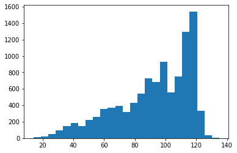

```python
import matplotlib.pyplot as plt

lengths=[]

for i in x_train:
    lengths.append(len(i))

%matplotlib inline
plt.hist(lengths,bins=25)
```

```python
print("90th percentile of all tweet character count volumes: {}".format(int(np.percentile(lengths, 90))))
```

```
90th percentile of all tweet character count volumes: 118
```

```python
from tensorflow.keras.preprocessing import sequence
# Because most of the reviews in the histogram above are length 23 or less, setting max_length to 23 words:
max_length = 118
x_train = sequence.pad_sequences(x_train, maxlen = max_length)
x_test = sequence.pad_sequences(x_test, maxlen = max_length)
```

```python
from tensorflow.keras.layers import Dense, Embedding
from tensorflow.keras.models import Sequential
from tensorflow.keras.preprocessing import sequence
from tensorflow.keras.layers import GRU
from tensorflow.keras.callbacks import EarlyStopping
```

```python
print("{} rows of {} sequences".format(x_train.shape[0], x_train.shape[1]))
```

```
10403 rows of 118 sequences
```

# **Unigram Model Output for Emoji Embedding**

```
WARNING:tensorflow:Layer gru will not use cuDNN kernel since it doesn't meet the cuDNN kernel criteria. It will use generic GPU kernel as fallback when running on GPU
Model: "sequential_1"
_________________________________________________________________
Layer (type)                 Output Shape              Param #
=================================================================
embedding_1 (Embedding)      (None, 118, 80)           19360
_________________________________________________________________
gru (GRU)                    (None, 100)               54600
_________________________________________________________________
dense (Dense)                (None, 3)                 303
=================================================================
Total params: 74,263
Trainable params: 74,263
Non-trainable params: 0
_________________________________________________________________
None
```

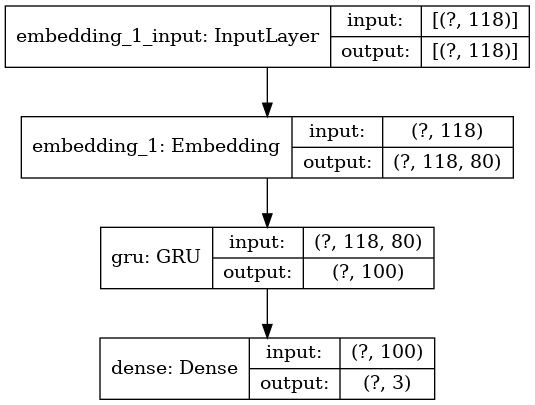

```python
from keras.utils import plot_model
callback = tf.keras.callbacks.EarlyStopping(monitor='loss', patience=3)

embedding_vector_length = 80
model_emoji = Sequential()
model_emoji.add(Embedding(len(dec), embedding_vector_length, input_length=max_length))
model_emoji.add(GRU(100, unroll=True, dropout=0.2)) # unroll makes this run faster; units between 100-300
model_emoji.add(Dense(3, activation='softmax')) # 3 for the three classes
model_emoji.compile(loss='sparse_categorical_crossentropy', optimizer='rmsprop', metrics=['accuracy']) # rmsprop did better than adam
print(model_emoji.summary())

plot_model(model_emoji, to_file='model_plot4a.png', show_shapes=True, show_layer_names=True)
```

```python
model_emojis = model_emoji.fit(x_train
                       , np.array(y_train)
                       , validation_data=(x_test, np.array(y_test))
                       , callbacks=[callback]
                       , epochs=20
                       , batch_size=32)
```

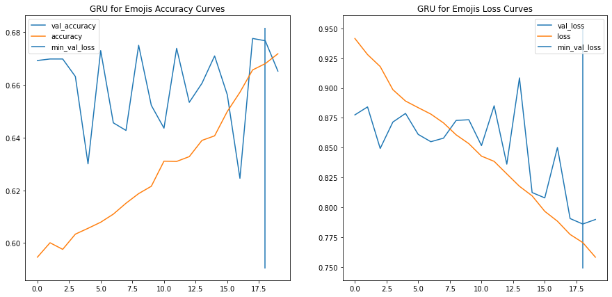

```python
val_loss = model_emojis.history['val_loss']
min_loss_loc = np.where(val_loss==np.min(val_loss))[0][0]

fig, ax = plt.subplots(ncols=2, figsize = (15,7))
ax[0].plot(model_emojis.history['val_accuracy'], label = 'val_accuracy')
ax[0].plot(model_emojis.history['accuracy'], label = 'accuracy')
ax[0].vlines(min_loss_loc, *ax[0].get_ylim(), label = 'min_val_loss')
ax[0].set_title('GRU for Emojis Accuracy Curves')
ax[0].legend();

ax[1].plot(model_emojis.history['val_loss'], label = 'val_loss')
ax[1].plot(model_emojis.history['loss'], label = 'loss')
ax[1].vlines(min_loss_loc, *ax[1].get_ylim(), label = 'min_val_loss')
ax[1].set_title('GRU for Emojis Loss Curves')
ax[1].legend();
```

# The vector learned for the emoji: 😂

Saving the Twitter model trained (includes emojis):

```python
model_emoji.save('./emoji_model.h5')
```

# Loading the Saved Model

```python
from tensorflow import keras
model_emoji = keras.models.load_model('./emoji_model.h5')
```

```
WARNING:tensorflow:Layer gru will not use cuDNN kernel since it doesn't meet the cuDNN kernel criteria. It will use generic GPU kernel as fallback when running on GPU
```

```python
embeddings = model_emoji.get_weights()[0]
```

Pickle the word list

```python
import pickle

with open("./word_list.txt", "wb") as wl:
    pickle.dump(word_list, wl)
```

# Load the word list from pickle (this is needed for the cosine similarity operation)

```python
import pickle

with open("./word_list.txt", "rb") as wl:
    word_list = pickle.load(wl)
```

#### Visualize all characters in the dictionary to visually inspect (and make sure target emoji is present).

#### Note: Pull a fresh set of dictionaries without the pad and unknown tokens:

```python
# put words into a dictionary for downstream use
import collections
def build_dataset(words):
    count = collections.Counter(words).most_common()
    dictionary = dict()
    for word, _ in count:
        dictionary[word] = len(dictionary)
    reverse_dictionary = dict(zip(dictionary.values(), dictionary.keys()))
    return dictionary, reverse_dictionary

def encode_decode(input):
    enc, dec = build_dataset(word_list)
    return enc, dec
```

```python
enc, dec = encode_decode(word_list)
```

```python
enc.items()
```

```
dict_items([('e', 0), ('t', 1), ('a', 2), ('o', 3), ('i', 4), ('n', 5), ('s', 6), ('r', 7), ('l', 8), ('h', 9), ('d', 10), ('u', 11), ('b', 12), ('m', 13), ('c', 14), ('#', 15), ('g', 16), ('p', 17), ('G', 18), ('y', 19), ('D', 20), ('O', 21), ('P', 22), ('w', 23), ('f', 24), ('@', 25), ('.', 26), (…
```

### Note: This needed to be run twice:

```python
enc = {value:key for key, value in enc.items()}
```

```python
enc = {value:key for key, value in enc.items()}
```

```python
# if you have access to the embedding layer explicitly
embeddings = model_emoji.get_weights()[0]

# `word_to_index` is a mapping (i.e. dict) from words to their index, e.g. `😂`: 85
words_embeddings = {w:embeddings[idx] for w, idx in enc.items()}
```

# This is the learned vector for 😂:

```python
# now you can use it like this for example
print(words_embeddings['😂'])
```

```
[ 0.3025325   0.5842908   0.42319667 -0.31405398  0.3698214   0.15363605
 -0.4177241  -0.22574772  0.00251621  0.00190915 -0.42551884 -0.0626784
  0.35473254  0.38380325  0.1223547   0.21410556 -0.23546855  0.16376063
 -0.26741436 -0.3407969   0.1284697  -0.58715177  0.42320794  0.41040668
 -0.26324856  0.21925806  0.02229878 -0.00487047  0.08724135  0.2913094
  0.01472738  0.16298081  0.5784312  -0.27969462 -0.16617207  0.22300777
  0.35038143  0.38679498 -0.29851472 -0.13641584 -0.18616225 -0.27854842
 -0.12230528 -0.25580463 -0.01578699 -0.15387978 -0.38997325 -0.53054965
  0.50691783  0.45597878  0.01528363 -0.30013585  0.1732997   0.34517664
 -0.13388382 -0.44196326 -0.55923593  0.31625775 -0.30021486 -0.16417497
 -0.39239502  0.43360528  0.187316   -0.4065224   0.33533433 -0.5363497
  0.318125    0.35078213 -0.08221983 -0.02760422 -0.27928853  0.2756848
 -0.38379908 -0.18375534 -0.5366697   0.08700037  0.29265705  0.43113294
  0.01999613  0.29827833]
```

```python
from spacy.vocab import Vocab

# Adding the vectors into spaCy vocab
vocab = Vocab()
for word, vector in words_embeddings.items():
    vocab.set_vector(word, vector)
```

```python
import numpy as np
from scipy.spatial import distance
import spacy

input_word = "😂"
p = np.array([vocab[input_word].vector])
```

```python
ids = [x for x in vocab.vectors.keys()]
vectors = [vocab.vectors[x] for x in ids]
vectors = np.array(vectors)
```

```python
most_similar = distance.cdist(p, vectors).argmin()
most_similar_char = ids[most_similar]
output_char = vocab[most_similar_char].text
```

```python
output_char
```

```
'😂'
```

# 3. What is the most similar character for the above emoji

## Populating a dataframe with the closest characters to the provided emoji (😂), by cosine distance.

## Scale: Values closest to 0 are closest to the emoji (😂). The most similar value is the double-quote (“)

```python
import scipy
import pandas as pd

dist_df = []

for k in dec.keys():
    dist_df.append(dec[k] + "~~~" + str(scipy.spatial.distance.cosine(words_embeddings['😂'], words_embeddings[dec[k]])))

distance_df = pd.DataFrame([sub.split("~~~") for sub in dist_df])

distance_df.columns = ['symbol','distance']

distance_df = distance_df.sort_values(by='distance').reset_index(drop=True)

distance_df.head()
```

|  | symbol | distance |
| --- | --- | --- |
| 0 | 😂 | 0.0 |
| 1 | “ | 0.05744379758834839 |
| 2 | 5 | 0.1289249062538147 |
| 3 | 😴 | 0.15175241231918335 |
| 4 | * | 0.1804565191268921 |

```python
print("The most similar emoji: [{}]\n\nCosine similarity (not distance) to this emoji: {}".format(distance_df.iloc[1,0], round(1-float(distance_df.iloc[1,1]), 4)))
```

```
The most similar emoji: [“]

Cosine similarity (not distance) to this emoji: 0.9426
```

```python
from gensim.models import Word2Vec, KeyedVectors
from gensim.test.utils import common_texts, get_tmpfile
```

```python
filename = './emoji2vec.bin'
e2v = KeyedVectors.load_word2vec_format(filename, binary=True)
```

```python
happy_vector = e2v['😂']
```

```python
happy_vector
```

```
array([ 0.00368995, -0.00747812,  0.04797658,  0.0592004 , -0.0594517 ,
       -0.01919357,  0.06628808, -0.06752758,  0.10211562,  0.087887  ,
       -0.02949324, -0.07718539, -0.07068242,  0.04688684, -0.07970048,
        0.09425059,  0.06230384,  0.09221437, -0.03019106, -0.08475313,
        0.06153254,  0.08948752,  0.07492744, -0.0697182 ,  0.02842957,
       -0.07775956, -0.00585377, -0.01818646,  0.07633407, -0.09874155,
       -0.05507204,  0.04539224,  0.00842756, -0.06562244, -0.04902945,
       -0.05832005,  0.07070394,  0.05070673,  0.05466724,  0.08123799,
        0.06764334, -0.09264724,  0.07862549, -0.03581576,  0.02264971,
       -0.00622183, -0.0318586 ,  0.0421854 , -0.05610641,  0.07420981,
       -0.06671992, -0.05842454,  0.03449175,  0.07620545,  0.08768762,
        0.03041447, -0.05500258, -0.03190211,  0.07291865, -0.04514114,
       -0.0541351 ,  0.05987531, -0.0346354 , -0.01317827,  0.00849659,
       -0.01372368, -0.01279207, -0.01283779, -0.07702036,  0.09149366,
        0.0390107 ,  0.07108027, -0.01238731,  0.08397982, -0.08521689,
       -0.06615324,  0.02603729,  0.07916152,  0.08146766,  0.09780202,
       -0.05352468,  0.03703088,  0.02943622, -0.0411319 , -0.08929481,
       -0.00907463, -0.07406733,  0.07654026,  0.07333956,  0.03913452,
       -0.03275327,  0.0839721 , -0.09473041, -0.02795571, -0.10102268,
        0.03562701,  0.06465388,  0.00239606, -0.01363948, -0.04439699,
       -0.0908874 ,  0.03828626,  0.03901853, -0.01020065, -0.00448968,
        0.07071512,  0.04707636,  0.00378791,  0.05759984,  0.01114361,
       -0.03391467,  0.00760981,  0.06322926, -0.0880087 ,  0.06876363,
       -0.07912473, -0.0028417 , -0.06997126,  0.02684613, -0.07514256,
       -0.07525261,  0.04538977, -0.01857131, -0.09254144,  0.01272622,
       -0.06651675, -0.07780645, -0.00054866,  0.01530222, -0.06704907,
       -0.09591693, -0.04216382, -0.05920067,  0.04180467, -0.08473751,
       -0.0091961 , -0.01856733,  0.06411888, -0.01504513,  0.00653571,
        0.03186707, -0.04212012,  0.07634199, -0.08881496, -0.07597502,
        0.03467466, -0.08546355, -0.05052061,  0.0900829 , -0.08306081,
        0.09260429,  0.08704868, -0.0360002 ,  0.02944678, -0.05743967,
       -0.00339006, -0.06426711,  0.04361258, -0.07921562, -0.0765662 ,
        0.01060756,  0.06268018,  0.08522304,  0.06723925,  0.07288557,
       -0.09302333,  0.02477937,  0.01172222,  0.00479384,  0.02157678,
        0.01548687, -0.07941901, -0.01285125, -0.01106149, -0.05682039,
        0.01480553,  0.07593461, -0.02521644,  0.0160483 , -0.02013016,
       -0.0006516 , -0.0474901 ,  0.079786  ,  0.08490966, -0.07243283,
        0.03765685, -0.08713188,  0.03943245, -0.06611194, -0.03412999,
        0.02676374, -0.07299029,  0.0697734 , -0.05803109,  0.08248405,
        0.06971692, -0.08738452, -0.00018618, -0.07082236, -0.04650601,
       -0.05312995,  0.0649436 , -0.05497617, -0.07783619,  0.06110686,
       -0.05441086, -0.0623476 ,  0.04429746, -0.05169839,  0.07030815,
       -0.04818415,  0.05482576, -0.05496503, -0.07783284, -0.08059028,
        0.06439808, -0.00520644, -0.0330755 , -0.07652996, -0.01107413,
       -0.00750746,  0.08184698,  0.04372175,  0.07949491, -0.00567428,
       -0.0624898 ,  0.02245951, -0.00251985, -0.02233904, -0.06598   ,
        0.05270914, -0.01273476, -0.08402091,  0.03170872,  0.03557813,
       -0.00872936, -0.0292008 , -0.05209661,  0.08882122,  0.08563904,
        0.06974573,  0.04504047, -0.06368353, -0.02415369, -0.07969051,
        0.09035778,  0.05923794,  0.04466449,  0.00783385, -0.03746437,
        0.00996592,  0.02965579,  0.05722547,  0.08226684,  0.01086137,
       -0.07542461, -0.07651414, -0.00404104, -0.08048932, -0.04402169,
       -0.07493835,  0.00871058,  0.03949443,  0.056054  ,  0.02210577,
        0.00656221,  0.02639471,  0.0557919 ,  0.01582586, -0.00514857,
       -0.05831469,  0.08793064,  0.08895694, -0.0292627 ,  0.07007831,
       -0.0333305 , -0.08543444, -0.00450068, -0.06502454, -0.00331638,
        0.06480967, -0.0196905 , -0.04076313,  0.02563368,  0.06550946,
       -0.06623957,  0.06932179,  0.03883428, -0.02262465,  0.03270576,
       -0.06228965,  0.01850435, -0.09290913, -0.05605437, -0.09467187,
       -0.0215614 , -0.02299731, -0.06261437,  0.00722107, -0.04899564],
      dtype=float32)
```

```python
result = e2v.most_similar("😂", topn=10)
```

```python
result
```

```
[('😹', 0.8721947073936462),
 ('😃', 0.6930503845214844),
 ('😆', 0.6827422976493835),
 ('😭', 0.671003520488739),
 ('😿', 0.6530009508132935),
 ('😢', 0.6413196325302124),
 ('😺', 0.619818925857544),
 ('😀', 0.5949568748474121),
 ('😊', 0.5913735032081604),
 ('☺️', 0.5856199264526367)]
```

```python
print("The most similar emoji: {}\n\nCosine similarity to this emoji: {}%".format(result[0][0], (100*round(result[0][1], 4))))
```

```
The most similar emoji: 😹

Cosine similarity to this emoji: 87.22%
```

# 4. Build a Universal Sentence Encoder (USE) Model and an RNN (RNN, LSTM, GRU, etc.) model for the following data set. Accuracy must be above 50%. Compare the results of the two in terms of time and accuracy.

http://cs.stanford.edu/people/alecmgo/trainingandtestdata.zip (first column is the polarity 0:negative, 4:positive).

## Comparative Performance Analysis: **Universal Sentence Encoder** versus **Gated Recurrent Unit**

```python
summary_data = {
    'Model':['Universal Sentence Encoder (batch size 128)','Universal Sentence Encoder (batch size 512)','Universal Sentence Encoder (batch size 2048)'
             ,'Gated Recurrent Unit (batch size 512)','Gated Recurrent Unit (batch size 2048)'],
    'Mean Accuracy (Training)':['0.8055','0.8016','0.8175', '0.8714','0.9442'],
    'Mean Accuracy (Validation)':['0.8018','0.7998', '0.8037','0.7956','0.7838'],
    'Mean Accuracy Ratio (Training/Validation)':['1.0046', '1.0023', '1.0172','1.0953','1.2046'],
    'Mean Loss (Training)':['0.4181','0.4255', '0.3982', '0.2997','0.1424'],
    'Mean Loss (Validation)':['0.4258','0.4278', '0.4216', '0.4629','0.5859'],
    'Mean Loss Ratio (Training/Validation)':['0.9819','0.9946','0.9445','0.6474','0.2430']}

pd.DataFrame(summary_data)
```

|  | Model | Mean Accuracy (Training) | Mean Accuracy (Validation) | Mean Accuracy Ratio (Training/Validation) | Mean Loss (Training) | Mean Loss (Validation) | Mean Loss Ratio (Training/Validation) |
| --- | --- | --- | --- | --- | --- | --- | --- |
| 0 | Universal Sentence Encoder (batch size 128) | 0.8055 | 0.8018 | 1.0046 | 0.4181 | 0.4258 | 0.9819 |
| 1 | Universal Sentence Encoder (batch size 512) | 0.8016 | 0.7998 | 1.0023 | 0.4255 | 0.4278 | 0.9946 |
| 2 | Universal Sentence Encoder (batch size 2048) | 0.8175 | 0.8037 | 1.0172 | 0.3982 | 0.4216 | 0.9445 |
| 3 | Gated Recurrent Unit (batch size 512) | 0.8714 | 0.7956 | 1.0953 | 0.2997 | 0.4629 | 0.6474 |
| 4 | Gated Recurrent Unit (batch size 2048) | 0.9442 | 0.7838 | 1.2046 | 0.1424 | 0.5859 | 0.2430 |

# **PART II: Universal Sentence Encoder Models**

```python
from tensorflow.keras.layers import Input, Dense, Dropout, Flatten, Lambda
import matplotlib.pyplot as plt
import tensorflow_hub as hub
import tensorflow as tf
import pandas as pd
import numpy as np
import os
import re
```

```python
print("Tensorflow Version:\n{}\n\nTensor-Hub Version:\n{}".format(tf.__version__, hub.__version__))
```

```
Tensorflow Version:
2.2.0

Tensor-Hub Version:
0.8.0
```

```python
!export CUDA_VISIBLE_DEVICES=0
```

```python
physical_devices = tf.config.experimental.list_physical_devices('GPU')
for physical_device in physical_devices:
    tf.config.experimental.set_memory_growth(physical_device, True)
```

```python
use_test = hub.KerasLayer("https://tfhub.dev/google/universal-sentence-encoder/4", trainable=False)
```

```python
data = pd.read_csv('./training.1600000.processed.noemoticon.csv', encoding = "ISO-8859-1", header=None)
```

```python
data = data[[0,5]]
```

This dataset needs to be shuffled. The original dataset is split - the first half is all class 0 and the second half is all class 4:

```python
# data.head()
```

|  | 0 | 5 |
| --- | --- | --- |
| 0 | 0 | @switchfoot http://twitpic.com/2y1zl - Awww, t... |
| 1 | 0 | is upset that he can't update his Facebook by ... |
| 2 | 0 | @Kenichan I dived many times for the ball. Man... |
| 3 | 0 | my whole body feels itchy and like its on fire |
| 4 | 0 | @nationwideclass no, it's not behaving at all.... |

```python
# data.tail()
```

|  | 0 | 5 |
| --- | --- | --- |
| 1599995 | 4 | Just woke up. Having no school is the best fee... |
| 1599996 | 4 | TheWDB.com - Very cool to hear old Walt interv... |
| 1599997 | 4 | Are you ready for your MoJo Makeover? Ask me f... |
| 1599998 | 4 | Happy 38th Birthday to my boo of alll time!!! ... |
| 1599999 | 4 | happy #charitytuesday @theNSPCC @SparksCharity... |

Shuffling the data:

```python
data = data.sample(frac=1.0, random_state=42).reset_index(drop=True)
```

```python
data.head(7)
```

|  | 0 | 5 |
| --- | --- | --- |
| 0 | 0 | @chrishasboobs AHHH I HOPE YOUR OK!!! |
| 1 | 0 | @misstoriblack cool , i have no tweet apps fo... |
| 2 | 0 | @TiannaChaos i know just family drama. its la... |
| 3 | 0 | School email won't open and I have geography ... |
| 4 | 0 | upper airways problem |
| 5 | 0 | Going to miss Pastor's sermon on Faith... |
| 6 | 4 | on lunch....dj should come eat with me |

```python
data.tail()
```

|  | 0 | 5 |
| --- | --- | --- |
| 1599995 | 0 | this song's middle change just doesn't want to... |
| 1599996 | 4 | @officialnjonas Good luck with that |
| 1599997 | 0 | @ProudGamerTweet I rather average 32370 |
| 1599998 | 0 | Pickin up @misstinayao waitin on @sadittysash ... |
| 1599999 | 0 | @ home studying for maths wooot ! im so going ... |

```python
# Bash to shuffle
#!shuf training.1600000.processed.noemoticon.csv > training.1600000.processed.noemoticon_shuffled.csv
# data = pd.read_csv('~/Desktop/DS7337 Natural Language Processing/Final_Exam/PART2_Data/training.1600000.processed.noemoticon_shuffled.csv', encoding = "ISO-8859-1", header=None)
```

```python
data.columns = ['polarity','text']
```

```python
data.head(2)
```

|  | polarity | text |
| --- | --- | --- |
| 0 | 0 | @chrishasboobs AHHH I HOPE YOUR OK!!! |
| 1 | 0 | @misstoriblack cool , i have no tweet apps fo... |

```python
len(data)
```

```
1600000
```

```python
data['polarity'].unique()
```

```
array([0, 4])
```

```python
data.polarity[data.polarity == 4] = 1
data.polarity[data.polarity == 0] = 0
```

```python
data['polarity'].unique()
```

```
array([0, 1])
```

Data is balanced on a perfect 50/50 split and has been randomly shuffled so I'll use a 50/50 test/validation split (downstream) since this gives a little more to the validation than a 75/25 (or similar) split:

```python
print("Balance of data classes: {}%".format(100*(round(data[data.polarity == 1].shape[0]/data.shape[0], 4))))
```

```
Balance of data classes: 50.0%
```

### Cleaning the data

Because this data appears to be from Twitter or some other platform that uses hashtags ("#") and mentions ("@"). Also, I'll leave only spaces and alphanumeric values

```python
data['text'] = data['text'].str.strip().str.lower()
data.text = data.text.str.replace(r"[^a-zA-Z0-9 ]", "")
```

```python
data.shape
```

```
(1600000, 2)
```

```python
data.head(2)
```

|  | polarity | text |
| --- | --- | --- |
| 0 | 0 | chrishasboobs ahhh i hope your ok |
| 1 | 0 | misstoriblack cool i have no tweet apps for ... |

For retweets, I'm removing the "RT" values

```python
for i in np.arange(0, len(data)):
    if data['text'][i].strip()[0:2] == "RT":
        data['text'][i] = data['text'][i][2:]
```

```python
data.shape
```

```
(1600000, 2)
```

```python
n=int(np.floor(data.shape[0]*0.5)) # 50% for training
train_df = data[0:n]
test_df = data[n:]
```

```python
train_df['polarity'].unique()
```

```
array([0, 1])
```

```python
test_df['polarity'].unique()
```

```
array([0, 1])
```

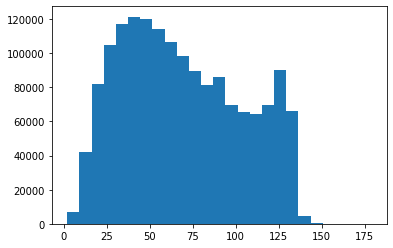

```python
import matplotlib.pyplot as plt

lengths=[]

for i in data['text']:
    lengths.append(len(i))

%matplotlib inline
plt.hist(lengths,bins=25)
```

```python
int(np.percentile(lengths, 95))
```

```
129
```

Two standard deviations cover 95 percent of the data in a normal distribution. Because this distribution is not perfectly normal, there is a slight difference (129 vs 139) when considering both tails (139) versus only the right tail (129). Nonetheless, this difference is relatively negligible.

```python
print([np.asarray(lengths).mean() - 2 * np.asarray(lengths).std(), np.asarray(lengths).mean() + 2 * np.asarray(lengths).std()])
```

```
[-0.3291617696097262, 138.79952301960972]
```

```python
max(lengths)
```

```
179
```

```python
X_train = train_df['text'].tolist()
X_train = [' '.join(t.split()[0:179]) for t in X_train]
X_train = np.array(X_train, dtype=object)[:, np.newaxis]
y_train = train_df['polarity']
```

```python
X_test = test_df['text'].tolist()
X_test = [' '.join(t.split()[0:179]) for t in X_test]
X_test = np.array(X_test, dtype=object)[:, np.newaxis]
y_test = test_df['polarity']
```

```python
labels = pd.concat([y_train, y_test], axis=0)
labels.shape
```

```
(1600000,)
```

```python
print("Train Data Length: {}\nValidation Data Length:{}".format(X_train.shape[0], X_test.shape[0]))
```

```
Train Data Length: 800000
Validation Data Length:800000
```

```python
def UniversalEmbedding(x):
    return use_test(tf.squeeze(tf.cast(x, tf.string)))
```

# Universal Sentence Encoder Model Results

```
Model: "model_1"
_________________________________________________________________
Layer (type)                 Output Shape              Param #
=================================================================
input_2 (InputLayer)         [(None,)]                 0
_________________________________________________________________
keras_layer_2 (KerasLayer)   (None, 512)               0
_________________________________________________________________
dense_3 (Dense)              (None, 256)               131328
_________________________________________________________________
output (Dense)               (None, 1)                 257
=================================================================
Total params: 131,585
Trainable params: 131,585
Non-trainable params: 0
_________________________________________________________________
```

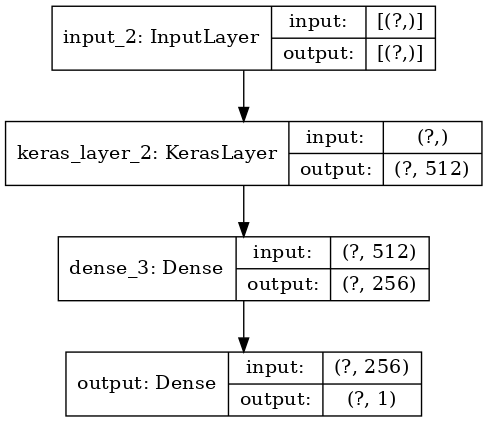

```python
callback = tf.keras.callbacks.EarlyStopping(monitor='loss', patience=3)
embed_size = 512 # since USE produces 512 vector lengths regardless of input size

input_text = Input(shape=(), dtype=tf.string) # leaving this as floating point

embedding = hub.KerasLayer(UniversalEmbedding, output_shape=(embed_size,))(input_text)

x = Dense(256, activation='relu')(embedding)
output = Dense(1,activation='sigmoid',name='output')(x) # sigmoid for 2-classes

model = tf.keras.Model(inputs=input_text, outputs=[output])

model.compile(loss='binary_crossentropy',
                  optimizer='rmsprop',
                  callbacks=[callback],
                  metrics=['accuracy'])
model.summary()
tf.keras.utils.plot_model(model, show_shapes=True, dpi=100)
```

### Batch size 128 yeilds mean runtime of 123.6 seconds, mean training accuracy 0.8055, and mean validation accuracy of 0.8018:

```python
hist = model.fit(X_train, np.array(y_train),
                 batch_size = 128,
                 epochs = 5,
                 callbacks = [callback],
                 validation_data=(X_test, np.array(y_test)))
```

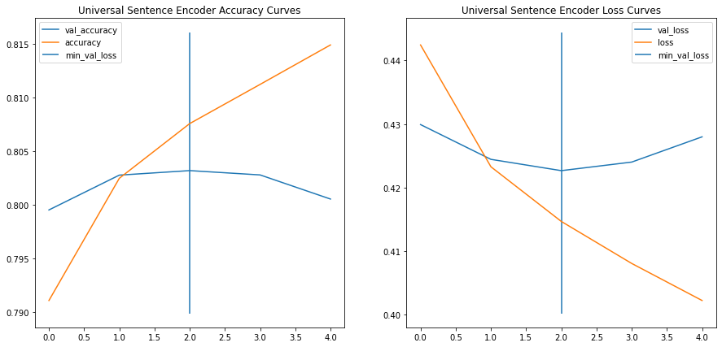

```python
val_loss = hist.history['val_loss']
min_loss_loc = np.where(val_loss==np.min(val_loss))[0][0]

fig, ax = plt.subplots(ncols=2, figsize = (15,7))
ax[0].plot(hist.history['val_accuracy'], label = 'val_accuracy')
ax[0].plot(hist.history['accuracy'], label = 'accuracy')
ax[0].vlines(min_loss_loc, *ax[0].get_ylim(), label = 'min_val_loss')
ax[0].set_title('Universal Sentence Encoder Accuracy Curves')
ax[0].legend();

ax[1].plot(hist.history['val_loss'], label = 'val_loss')
ax[1].plot(hist.history['loss'], label = 'loss')
ax[1].vlines(min_loss_loc, *ax[1].get_ylim(), label = 'min_val_loss')
ax[1].set_title('Universal Sentence Encoder Loss Curves')
ax[1].legend();
```

### Batch size 512 yeilds mean runtime of 70.8 seconds, mean training accuracy 0.8016, and mean validation accuracy of 0.7998:

```python
hist = model.fit(X_train, np.array(y_train),
                 batch_size = 512,
                 epochs = 5,
                 callbacks = [callback],
                 validation_data=(X_test, np.array(y_test)))
```

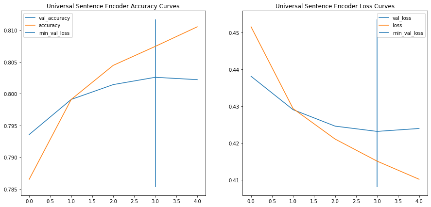

```python
val_loss = hist.history['val_loss']
min_loss_loc = np.where(val_loss==np.min(val_loss))[0][0]

fig, ax = plt.subplots(ncols=2, figsize = (15,7))
ax[0].plot(hist.history['val_accuracy'], label = 'val_accuracy')
ax[0].plot(hist.history['accuracy'], label = 'accuracy')
ax[0].vlines(min_loss_loc, *ax[0].get_ylim(), label = 'min_val_loss')
ax[0].set_title('Universal Sentence Encoder Accuracy Curves')
ax[0].legend();

ax[1].plot(hist.history['val_loss'], label = 'val_loss')
ax[1].plot(hist.history['loss'], label = 'loss')
ax[1].vlines(min_loss_loc, *ax[1].get_ylim(), label = 'min_val_loss')
ax[1].set_title('Universal Sentence Encoder Loss Curves')
ax[1].legend();
```

### Batch size 2048 yeilds mean runtime of 51.2 seconds, mean training accuracy 0.8175, and mean validation accuracy of 0.8037:

```python
hist = model.fit(X_train, np.array(y_train),
                 batch_size = 2048,
                 epochs = 5,
                 callbacks = [callback],
                 validation_data=(X_test, np.array(y_test)))
```

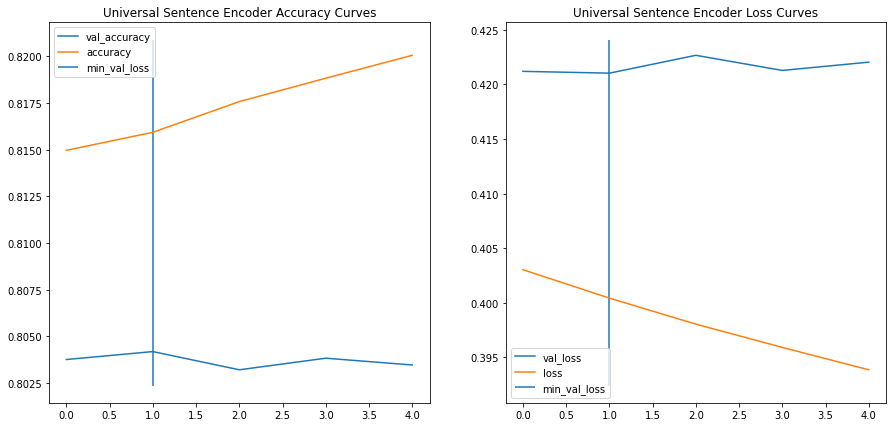

```python
val_loss = hist.history['val_loss']
min_loss_loc = np.where(val_loss==np.min(val_loss))[0][0]

fig, ax = plt.subplots(ncols=2, figsize = (15,7))
ax[0].plot(hist.history['val_accuracy'], label = 'val_accuracy')
ax[0].plot(hist.history['accuracy'], label = 'accuracy')
ax[0].vlines(min_loss_loc, *ax[0].get_ylim(), label = 'min_val_loss')
ax[0].set_title('Universal Sentence Encoder Accuracy Curves')
ax[0].legend();

ax[1].plot(hist.history['val_loss'], label = 'val_loss')
ax[1].plot(hist.history['loss'], label = 'loss')
ax[1].vlines(min_loss_loc, *ax[1].get_ylim(), label = 'min_val_loss')
ax[1].set_title('Universal Sentence Encoder Loss Curves')
ax[1].legend();
```

# **PART II: Gated Recurrent Unit Models**

```python
import matplotlib.pyplot as plt
import tensorflow_hub as hub
import tensorflow as tf
import pandas as pd
import numpy as np
import os
import re
```

```python
!export CUDA_VISIBLE_DEVICES=0
```

```python
physical_devices = tf.config.experimental.list_physical_devices('GPU')
for physical_device in physical_devices:
    tf.config.experimental.set_memory_growth(physical_device, True)
```

```python
data = pd.read_csv('./training.1600000.processed.noemoticon.csv', encoding = "ISO-8859-1", header=None)
```

```python
data = data.sample(frac=1.0, random_state=42).reset_index(drop=True)
```

```python
data = data[[0,5]]
```

```python
data.columns = ['polarity','text']
```

```python
data.polarity[data.polarity == 4] = 1
data.polarity[data.polarity == 0] = 0
```

```python
data['polarity'].unique()
```

```
array([0, 1])
```

```python
print("Balance of data classes: {}%".format(100*(round(data[data.polarity == 1].shape[0]/data.shape[0], 4))))
```

```
Balance of data classes: 50.0%
```

```python
data['text'] = data['text'].str.strip().str.lower()
data.text = data.text.str.replace(r"[^a-zA-Z0-9 ]", "")
```

```python
for i in np.arange(0, len(data)):
    if data['text'][i].strip()[0:2] == "RT":
        data['text'][i] = data['text'][i][2:]
```

```python
n=int(np.floor(data.shape[0]*0.5)) # 50% for training
train_df = data[0:n]
test_df = data[n:]
```

```python
train_df['polarity'].unique()
```

```
array([0, 1])
```

```python
data.head()
```

|  | polarity | text |
| --- | --- | --- |
| 0 | 0 | chasingthomas im gutted he hasnt accepted me y... |
| 1 | 1 | so thankful for first time families to kidspring |
| 2 | 1 | texasjackflash same to you sir |
| 3 | 1 | maraboyce thank youu i worked hard on in this... |
| 4 | 0 | dazzledust25 im good thanks shatterd from work... |

```python
data.tail()
```

|  | polarity | text |
| --- | --- | --- |
| 1599995 | 1 | yoitsjonah you should rj gigil |
| 1599996 | 0 | shamarie11 i wish we had the to go for a week... |
| 1599997 | 1 | rockeye justads oh you kids |
| 1599998 | 1 | baked a cake amp watching a movie |
| 1599999 | 0 | mandafa i saw those and was like who are the... |

```python
data.head(2)
```

|  | polarity | text |
| --- | --- | --- |
| 0 | 0 | chasingthomas im gutted he hasnt accepted me y... |
| 1 | 1 | so thankful for first time families to kidspring |

```python
# put words into a dictionary for downstream use
import collections

def build_dataset(words):
    count = collections.Counter(words).most_common() #.most_common(100) to use the 100 most common words; .most_common() means zero is the most common
    dictionary = dict()
    for word, _ in count:
        dictionary[word] = len(dictionary)
    reverse_dictionary = dict(zip(dictionary.values(), dictionary.keys()))
    return dictionary, reverse_dictionary
```

```python
word_list=[]
flat_list = []

for i in np.arange(len(data)):
    word_list.append(data['text'][i].split())
```

```python
flat_list = []
for sublist in word_list:
    for item in sublist:
        flat_list.append(item)
```

```python
word_list = flat_list.copy()
```

```python
len(word_list)
```

```
20846612
```

```python
words_unique = set(word_list)
```

```python
len(words_unique)
```

```
839946
```

```python
def encode_decode(input):
    enc, dec = build_dataset(word_list)
    return enc, dec
```

```python
enc, dec = encode_decode(word_list)
```

```python
for i in enc:
    enc[i] = enc[i]+2 # shift everything by two so you can put in a pad and an unknown in index locations 0 and 1

                                                                    ###      ###
                                                                    # Encoding #
                                                                    ###      ###
enc['pad'] = 0

# start is useful for more complex architectures to invoke the LSTM to perform certain tasks, like decoding or recognizing the start of a sentence, for example.
#enc['<start>'] = 1

enc['<unk>'] = 1

                                                                    ###      ###
                                                                    # Decoding #
                                                                    ###      ###

# pad and include an unknown for the decoded values as well
dec[-2]='<pad>'
#dec[-1]='<start>'
dec[-1]='<unk>' # this is useful to indicate the LSTM should start decoding, or that this is the start of a sentence, or etc.
```

```python
data['y'] = 0
data.loc[data['polarity']==1,'y'] = 1
```

```python
print("Balance of data classes: {}%".format(100*(round(data[data.polarity == 1].shape[0]/data.shape[0], 4))))
```

```
Balance of data classes: 50.0%
```

```python
import numpy as np
n=int(np.floor(data.shape[0]*0.50)) # 50% for training since target classes are balanced
train = data[0:n]
test = data[n:]
```

```python
len(train)
```

```
800000
```

```python
len(test)
```

```
800000
```

```python
train['y'].value_counts()
```

```
1    400234
0    399766
Name: y, dtype: int64
```

```python
test['y'].value_counts()
```

```
0    400234
1    399766
Name: y, dtype: int64
```

```python
x_train=[]
y_train=[]

for i in range(train.shape[0]):
    tmp = [enc[j] for j in train.iloc[i,1].split()] # enc[j]: the j (list expression) is encoding the number for the word in the encoded matrix (i,j)
    x_train.append(tmp) # append the newly replaced word
    if train.iloc[i,0]==0: # re-encode y in the below
        y=0
    else:
        y=1
    y_train.append(y) # append the newly encoded y here

x_test=[] # repeat for the test data the steps performed above for training data
y_test=[]
for i in range(test.shape[0]):
    tmp = [enc[j] for j in test.iloc[i,1].split()]
    x_test.append(tmp)
    if test.iloc[i,0]==0: # re-encode y in the below
        y=0
    else:
        y=1
    y_test.append(y)
```

```python
len(x_train)
```

```
800000
```

```python
len(y_train)
```

```
800000
```

```python
len(x_test)
```

```
800000
```

```python
len(y_test)
```

```
800000
```

```python
np.unique(y_train)
```

```
array([0, 1])
```

```python
np.unique(y_test)
```

```
array([0, 1])
```

```python
# The first time this runs, i-2 will remove the decoded pad and unknown variables used to prevent over-fitting
[dec[i-2] for i in x_train[1]]
```

```
['so', 'thankful', 'for', 'first', 'time', 'families', 'to', 'kidspring']
```

```python
data.iloc[1,1]
```

```
'so thankful for first time families to kidspring'
```

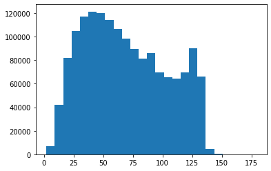

```python
import matplotlib.pyplot as plt

lengths=[]

for i in data['text']:
    lengths.append(len(i))

%matplotlib inline
plt.hist(lengths,bins=25)
```

```python
int(np.percentile(lengths, 95))
```

```
129
```

```python
from tensorflow.keras.preprocessing import sequence

max_length = 129
x_train = sequence.pad_sequences(x_train, maxlen = max_length)
x_test = sequence.pad_sequences(x_test, maxlen = max_length)
```

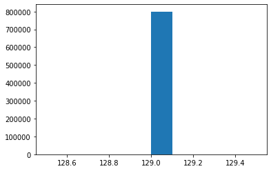

```python
%matplotlib inline
import matplotlib.pyplot as plt
plt.hist([len(i) for i in x_train])
plt.show()
### Note that after padding, all sentences are the same length (same number of parameters)
```

```python
from tensorflow.keras.layers import Dense
from tensorflow.keras.layers import Embedding
from tensorflow.keras.models import Sequential
from tensorflow.keras.preprocessing import sequence
from tensorflow.keras.layers import GRU
from tensorflow.keras.callbacks import TensorBoard, EarlyStopping, ModelCheckpoint
from tensorflow.keras.preprocessing.text import Tokenizer
```

# Gated Recurrent Unit Model Results

```
WARNING:tensorflow:Layer gru_1 will not use cuDNN kernel since it doesn't meet the cuDNN kernel criteria. It will use generic GPU kernel as fallback when running on GPU
Model: "sequential_1"
_________________________________________________________________
Layer (type)                 Output Shape              Param #
=================================================================
embedding_1 (Embedding)      (None, 129, 180)          151190640
_________________________________________________________________
gru_1 (GRU)                  (None, 300)               433800
_________________________________________________________________
dense_1 (Dense)              (None, 1)                 301
=================================================================
Total params: 151,624,741
Trainable params: 151,624,741
Non-trainable params: 0
_________________________________________________________________
None
```

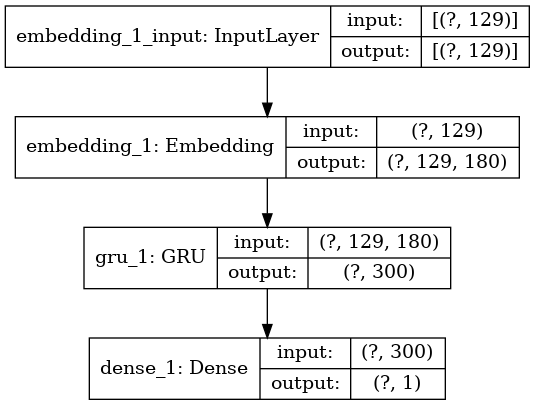

```python
from keras.utils import plot_model
max_length = 129
embedding_vector_length = 180

model1 = Sequential()
model1.add(Embedding(len(dec), embedding_vector_length, input_length=max_length)) # create the embedding vectors
model1.add(GRU(300, unroll=True, dropout=0.2)) # unroll makes this run faster; units between 100-300
model1.add(Dense(1, activation='sigmoid')) # 1 for the two classes
model1.compile(loss='binary_crossentropy', optimizer='rmsprop', metrics=['accuracy']) # binary crossentropy for the two classes + sigmoid
print(model1.summary())

plot_model(model1, to_file='model_plot4a.png', show_shapes=True, show_layer_names=True)
```

```python
np.unique(y_train)
```

```
array([0, 1])
```

```python
np.unique(y_test)
```

```
array([0, 1])
```

```python
np.array(y_train).shape
```

```
(800000,)
```

```python
np.array(y_test).shape
```

```
(800000,)
```

```python
x_train.shape
```

```
(800000, 129)
```

```python
x_test.shape
```

```
(800000, 129)
```

(sanity check to make sure input variable datasets are rectangular and there are no ragged edges)

```python
def rectangular(List):
    n = List
    for i in n:
        if len(i) != len(n[0]):
            return False
    return True
```

```python
print("The data is rectangular (True or False):\n{}".format(rectangular(x_test)))
```

[output not shown]

### Batch size 512 yeilds mean runtime of 1098.8 seconds, mean training accuracy 0.8714, and mean validation accuracy of 0.7956:

```python
callback = tf.keras.callbacks.EarlyStopping(monitor='loss', patience=3)

model_GRU = model1.fit(x_train
                       , np.array(y_train)
                       , validation_data=(x_test, np.array(y_test))
                       , callbacks = [callback]
                       , epochs=5
                       , batch_size=512)
```

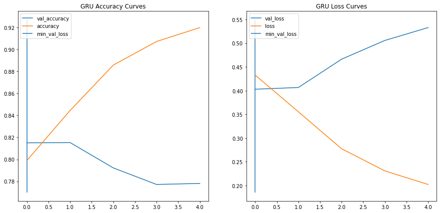

```python
val_loss = model_GRU.history['val_loss']
min_loss_loc = np.where(val_loss==np.min(val_loss))[0][0]

fig, ax = plt.subplots(ncols=2, figsize = (15,7))
ax[0].plot(model_GRU.history['val_accuracy'], label = 'val_accuracy')
ax[0].plot(model_GRU.history['accuracy'], label = 'accuracy')
ax[0].vlines(min_loss_loc, *ax[0].get_ylim(), label = 'min_val_loss')
ax[0].set_title('GRU Accuracy Curves')
ax[0].legend();

ax[1].plot(model_GRU.history['val_loss'], label = 'val_loss')
ax[1].plot(model_GRU.history['loss'], label = 'loss')
ax[1].vlines(min_loss_loc, *ax[1].get_ylim(), label = 'min_val_loss')
ax[1].set_title('GRU Loss Curves')
ax[1].legend();
```

### Batch size 2048 yeilds mean runtime of 336.6 seconds, mean training accuracy 0.9442, and mean validation accuracy of 0.7838:

```python
callback = tf.keras.callbacks.EarlyStopping(monitor='loss', patience=3)

model_GRU = model1.fit(x_train
                       , np.array(y_train)
                       , validation_data=(x_test, np.array(y_test))
                       , callbacks = [callback]
                       , epochs=5
                       , batch_size=2048)
```

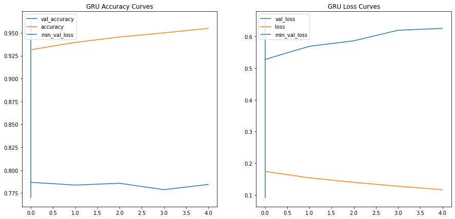

```python
val_loss = model_GRU.history['val_loss']
min_loss_loc = np.where(val_loss==np.min(val_loss))[0][0]

fig, ax = plt.subplots(ncols=2, figsize = (15,7))
ax[0].plot(model_GRU.history['val_accuracy'], label = 'val_accuracy')
ax[0].plot(model_GRU.history['accuracy'], label = 'accuracy')
ax[0].vlines(min_loss_loc, *ax[0].get_ylim(), label = 'min_val_loss')
ax[0].set_title('GRU Accuracy Curves')
ax[0].legend();

ax[1].plot(model_GRU.history['val_loss'], label = 'val_loss')
ax[1].plot(model_GRU.history['loss'], label = 'loss')
ax[1].vlines(min_loss_loc, *ax[1].get_ylim(), label = 'min_val_loss')
ax[1].set_title('GRU Loss Curves')
ax[1].legend();
```